# Code: Analysis of messaging and financing on demand for non-traditional cookstove adoption in Uganda

### 4.1.2 Bidprices with Wealth Variables

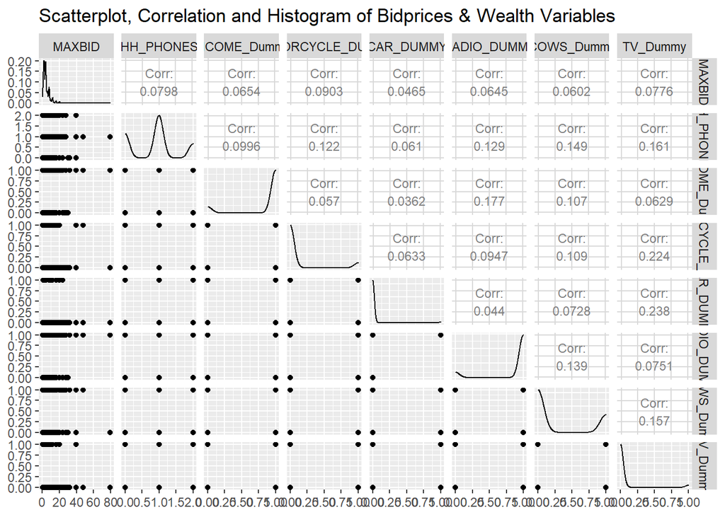

```r
### Bidprice with Wealth
ggp7=ggpairs(data_plus,upper = list(continuous = wrap("cor", size = 3)), columns=c(which(colnames(data_plus)=="MAXBID"),which(colnames(data_plus)=="HH_PHONES"),which(colnames(data_plus)=="INCOME_Dummy"),which(colnames(data_plus)==" BICYCLE_DUMMY"),which(colnames(data_plus)=="MOTORCYCLE_DUMMY"),which(colnames(data_plus)=="CAR_DUMMY"),which(colnames(data_plus)=="RADIO_DUMMY"),which(colnames(data_plus)==" MAINEMPLOYER") ,which(colnames(data_plus)=="TIME_EMPLOYED "),which(colnames(data_plus)=="COWS_Dummy"),which(colnames(data_plus)=="TV_Dummy")))
print(ggp7 + ggtitle("Scatterplot, Correlation and Histogram of Bidprices & Wealth Variables"))
```

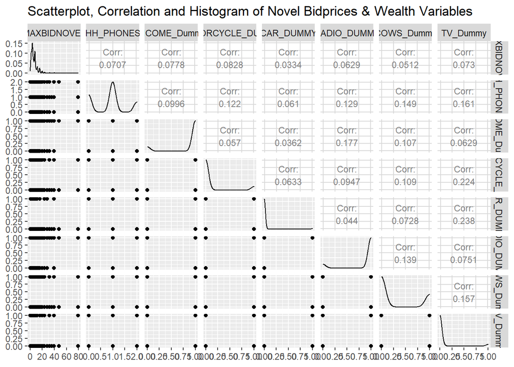

```r
### Novel bidprice with Wealth
ggp8=ggpairs(data_plus,upper = list(continuous = wrap("cor", size = 3)), columns=c(which(colnames(data_plus)=="MAXBIDNOVEL"),which(colnames(data_plus)=="HH_PHONES"),which(colnames(data_plus)=="INCOME_Dummy"),which(colnames(data_plus)==" BICYCLE_DUMMY"),which(colnames(data_plus)=="MOTORCYCLE_DUMMY"),which(colnames(data_plus)=="CAR_DUMMY"),which(colnames(data_plus)=="RADIO_DUMMY"),which(colnames(data_plus)==" MAINEMPLOYER") ,which(colnames(data_plus)=="TIME_EMPLOYED "),which(colnames(data_plus)=="COWS_Dummy"),which(colnames(data_plus)=="TV_Dummy")))
print(ggp8 + ggtitle("Scatterplot, Correlation and Histogram of Novel Bidprices & Wealth Variables"))
```

It shows that all the wealth variables have small correlation with either bidprices or novel bidprices, but more consistently, larger than the correlation between socio-economic variables

### 4.1.3 Bidprices with Cookstove Variables

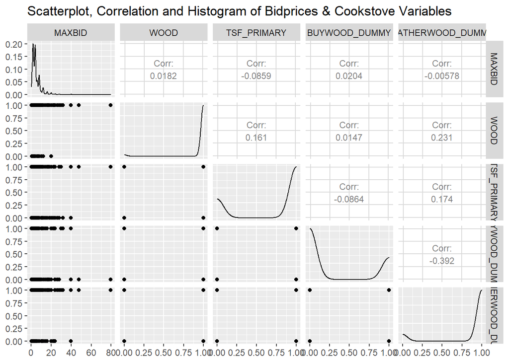

```r
### Bidprice with Cookstove
ggp9=ggpairs(data_plus,upper = list(continuous = wrap("cor", size = 3)), columns=c(which(colnames(data_plus)=="MAXBID"),which(colnames(data_plus)=="WOOD"),which(colnames(data_plus)=="TSF_PRIMARY"),which(colnames(data_plus)=="BUYWOOD_DUMMY"),which(colnames(data_plus)=="GATHERWOOD_DUMMY")))
print(ggp9 + ggtitle("Scatterplot, Correlation and Histogram of Bidprices & Cookstove Variables"))
```

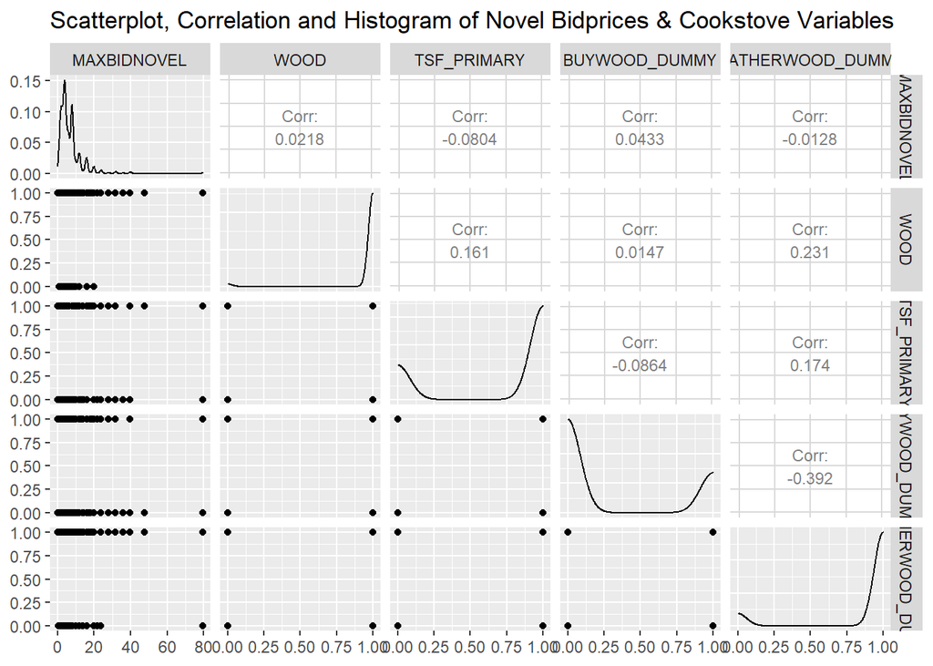

```r
### Novel bidprice with Cookstove
ggp10=ggpairs(data_plus,upper = list(continuous = wrap("cor", size = 3)), columns=c(which(colnames(data_plus)=="MAXBIDNOVEL"),which(colnames(data_plus)=="WOOD"),which(colnames(data_plus)=="TSF_PRIMARY"),which(colnames(data_plus)=="BUYWOOD_DUMMY"),which(colnames(data_plus)=="GATHERWOOD_DUMMY")))
print(ggp10 + ggtitle("Scatterplot, Correlation and Histogram of Novel Bidprices & Cookstove Variables"))
```

### 4.1.4 Gender Interaction Term First, create the interactions

```r
### Gender with Socio−Economic Variables
data_plus$Female_AGE=data_plus$AGE*data_plus$FEMALE
data_plus$Female_MARRIED=data_plus$MARRIED*data_plus$FEMALE
data_plus$Female_WIFECOOK=data_plus$WIFECOOK*data_plus$FEMALE
data_plus$Female_JOINTDECISION=data_plus$JOINTDECISION*data_plus$FEMALE
data_plus$Female_KNOWLUNCH_Dummy=data_plus$KNOWLUNCH_Dummy*data_plus$FEMALE
data_plus$Female_LUNCHYESTERDAY=data_plus$LUNCHYESTERDAY*data_plus$FEMALE

### Gender with Wealth
data_plus$Female_HH_PHONES=data_plus$HH_PHONES*data_plus$FEMALE
data_plus$Female_INCOME_Dummy=data_plus$INCOME_Dummy*data_plus$FEMALE
data_plus$Female_MOTORCYCLE_DUMMY=data_plus$MOTORCYCLE_DUMMY*data_plus$FEMALE
data_plus$Female_CAR_DUMMY=data_plus$CAR_DUMMY*data_plus$FEMALE
data_plus$Female_RADIO_DUMMY=data_plus$RADIO_DUMMY*data_plus$FEMALE
data_plus$Female_COWS_Dummy=data_plus$COWS_Dummy*data_plus$FEMALE
data_plus$Female_TV_Dummy=data_plus$TV_Dummy*data_plus$FEMALE

### Gender with Cookstove
data_plus$Female_WOOD=data_plus$WOOD*data_plus$FEMALE
data_plus$Female_TSF_PRIMARY=data_plus$TSF_PRIMARY*data_plus$FEMALE
data_plus$Female_BUYWOOD_DUMMY=data_plus$BUYWOOD_DUMMY*data_plus$FEMALE
data_plus$Female_GATHERWOOD_DUMMY=data_plus$GATHERWOOD_DUMMY*data_plus$FEMALE
data_plus$Female_TotalAsset = data_plus$ASSET_TOTAL*data_plus$FEMALE
```

Second, check the correlations #### 1) Bidprices with Gender * Socio-econ Demographic Variables

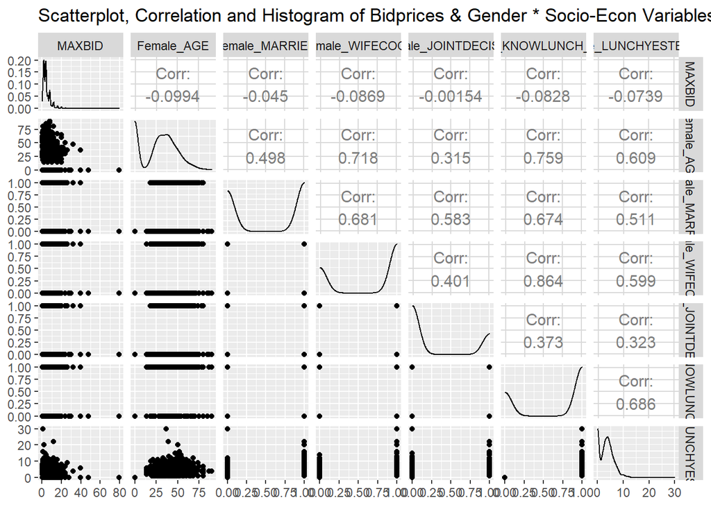

```r
### Bidprice with Gender*Socio-Econ Variables
ggp11=ggpairs(data_plus,upper = list(continuous = wrap("cor", size = 4)), columns=c(which(colnames(data_plus)=="MAXBID"),which(colnames(data_plus)=="Female_AGE"),which(colnames(data_plus)=="Female_MARRIED"),which(colnames(data_plus)=="Female_WIFECOOK"),which(colnames(data_plus)=="Female_JOINTDECISION"),which(colnames(data_plus)=="Female_KNOWLUNCH_Dummy"),which(colnames(data_plus)=="Female_LUNCHYESTERDAY") ))
print(ggp11 + ggtitle("Scatterplot, Correlation and Histogram of Bidprices & Gender * Socio-Econ Variables"))
```

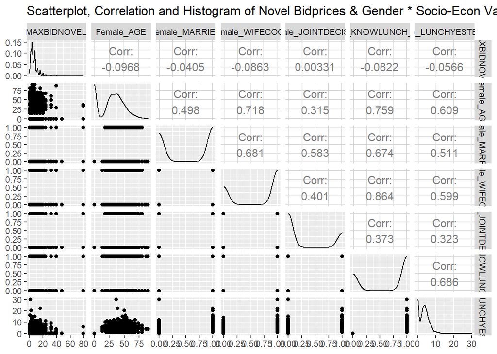

```r
### Novel bidprice with Gender*Socio-Econ Variables
ggp12=ggpairs(data_plus,upper = list(continuous = wrap("cor", size = 4)), columns=c(which(colnames(data_plus)=="MAXBIDNOVEL"),which(colnames(data_plus)=="Female_AGE"),which(colnames(data_plus)=="Female_MARRIED"),which(colnames(data_plus)=="Female_WIFECOOK"),which(colnames(data_plus)=="Female_JOINTDECISION"),which(colnames(data_plus)=="Female_KNOWLUNCH_Dummy"),which(colnames(data_plus)=="Female_LUNCHYESTERDAY") ))
print(ggp12 + ggtitle("Scatterplot, Correlation and Histogram of Novel Bidprices & Gender * Socio-Econ Variables"))
```

#### 2) Bidprices with Gender * Wealth Variables

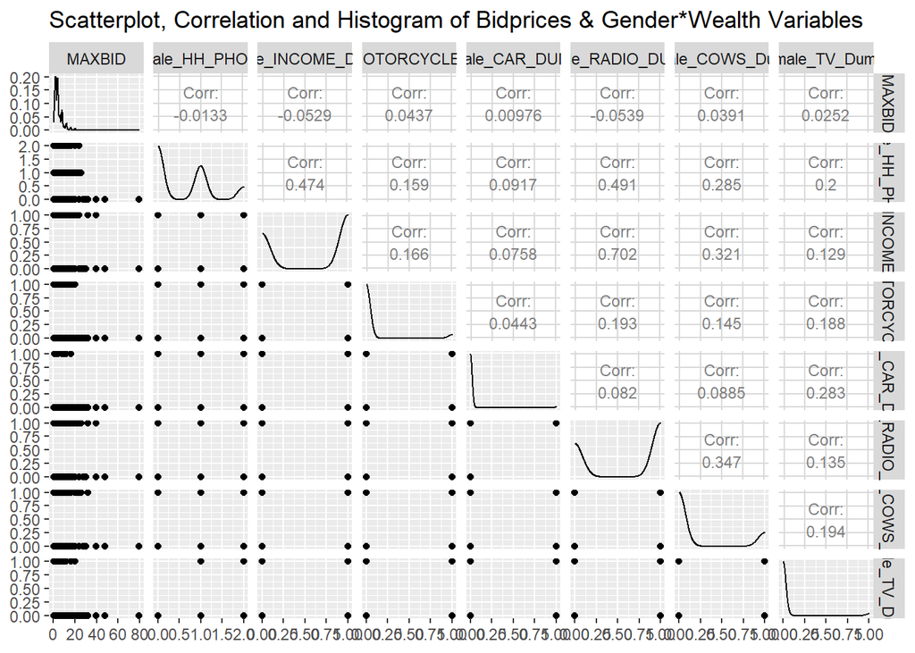

```r
### Bidprice with Gender*Wealth
ggp13=ggpairs(data_plus,upper = list(continuous = wrap("cor", size = 3)), columns=c(which(colnames(data_plus)=="MAXBID"),which(colnames(data_plus)=="Female_HH_PHONES"),which(colnames(data_plus)=="Female_INCOME_Dummy"),which(colnames(data_plus)==" Female_BICYCLE_DUMMY"),which(colnames(data_plus)=="Female_MOTORCYCLE_DUMMY"),which(colnames(data_plus)=="Female_CAR_DUMMY"),which(colnames(data_plus)=="Female_RADIO_DUMMY"),which(colnames(data_plus)=="Female_MAINEMPLOYER") ,which(colnames(data_plus)=="Female_TIME_EMPLOYED "),which(colnames(data_plus)=="Female_COWS_Dummy"),which(colnames(data_plus)=="Female_TV_Dummy")))
print(ggp13 + ggtitle("Scatterplot, Correlation and Histogram of Bidprices & Gender*Wealth Variables"))
```

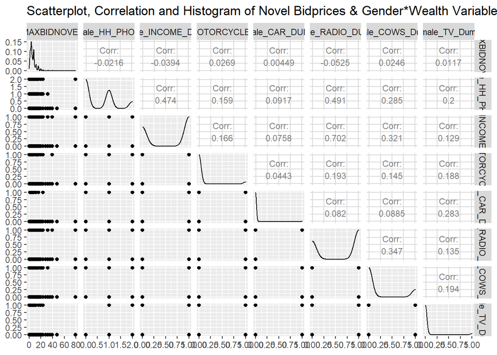

```r
### Novel bidprice with Gender*Wealth
ggp14=ggpairs(data_plus,upper = list(continuous = wrap("cor", size = 3)), columns=c(which(colnames(data_plus)=="MAXBIDNOVEL"),which(colnames(data_plus)=="Female_HH_PHONES"),which(colnames(data_plus)=="Female_INCOME_Dummy"),which(colnames(data_plus)=="Female_BICYCLE_DUMMY"),which(colnames(data_plus)=="Female_MOTORCYCLE_DUMMY"),which(colnames(data_plus)=="Female_CAR_DUMMY"),which(colnames(data_plus)=="Female_RADIO_DUMMY"),which(colnames(data_plus)=="Female_MAINEMPLOYER") ,which(colnames(data_plus)=="Female_TIME_EMPLOYED "),which(colnames(data_plus)=="Female_COWS_Dummy"),which(colnames(data_plus)=="Female_TV_Dummy")))
print(ggp14 + ggtitle("Scatterplot, Correlation and Histogram of Novel Bidprices & Gender*Wealth Variables"))
```

#### 3) Bidprices with Gender * Cookstove Variables

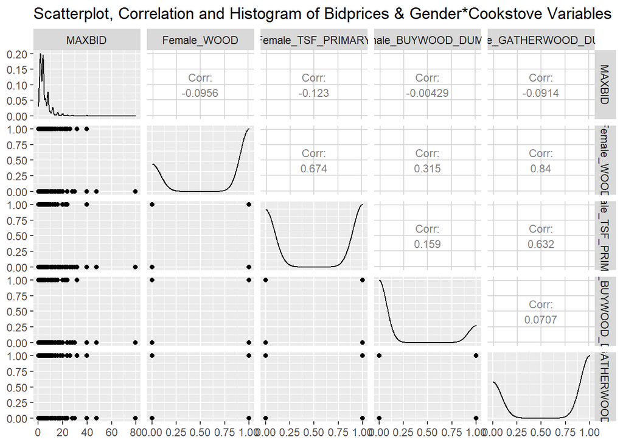

```r
### Bidprice with Cookstove
ggp15=ggpairs(data_plus,upper = list(continuous = wrap("cor", size = 3)), columns=c(which(colnames(data_plus)=="MAXBID"),which(colnames(data_plus)=="Female_WOOD"),which(colnames(data_plus)=="Female_TSF_PRIMARY"),which(colnames(data_plus)=="Female_BUYWOOD_DUMMY"),which(colnames(data_plus)=="Female_GATHERWOOD_DUMMY")))
print(ggp15 + ggtitle("Scatterplot, Correlation and Histogram of Bidprices & Gender*Cookstove Variables"))
```

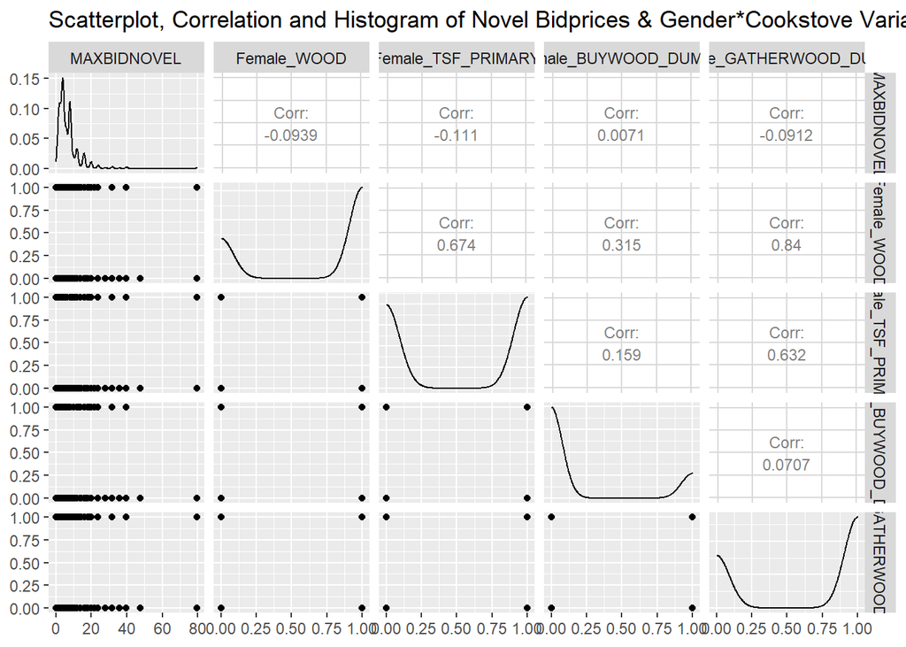

```r
### Novel bidprice with Cookstove
ggp16=ggpairs(data_plus,upper = list(continuous = wrap("cor", size = 3)), columns=c(which(colnames(data_plus)=="MAXBIDNOVEL"),which(colnames(data_plus)=="Female_WOOD"),which(colnames(data_plus)=="Female_TSF_PRIMARY"),which(colnames(data_plus)=="Female_BUYWOOD_DUMMY"),which(colnames(data_plus)=="Female_GATHERWOOD_DUMMY")))
print(ggp16 + ggtitle("Scatterplot, Correlation and Histogram of Novel Bidprices & Gender*Cookstove Variables"))
```

### 4.1.5 Important Varibles Noted

*Absolute value of correlation - 1%*  
AGE, FEMALE, WIFECOOK, KNOWLUNCH_DUMMY, WOOD, BUYWOOD.

*Absolute value of correlation - <1%*  
GATHERWOOD_DUMMY, LUNCHYESTERDAY, KNOWLUNCH_Dummy

*Save the augmented data*  
After combine the asset variable created, we form a data_plus file, both in csv and dta.

```r
### save the expanding dataset
write.csv(data_plus,"data_plus.csv")
```

```r
library(foreign)
write.dta(data_plus, "data_plus.dta")
```

## 4.2 Simple linear regressions

The results are the base for section 4, which will be discussed later.

# 5 Bidprices on group and explanatory variables (fixed effect) - table 4,5 and 6

District FE Survey Day FE

pay within week vs four weeks.  
*Note: NA as a coefficient in a regression indicates that the variable in question is linearly related to the other variables.*

```r
### run a pair of models without fixed effects
lm1 = lm(MAXBID ~ Improves_Health+Time_Money+Time_Money_Health, data = data_plus)
summary(lm1)
```

```
##
## Call:
## lm(formula = MAXBID ~ Improves_Health + Time_Money + Time_Money_Health,
##     data = data_plus)
##
## Residuals:
##    Min     1Q Median     3Q    Max
## -5.304 -2.595 -0.903  1.381 74.939
##
## Coefficients:
##                   Estimate Std. Error t value Pr(>|t|)
## (Intercept)         4.5834     0.1990  23.032  < 2e-16 ***
## Improves_Health     0.9197     0.2840   3.239  0.00122 **
## Time_Money         -0.1083     0.2861  -0.379  0.70503
## Time_Money_Health   0.2956     0.2820   1.049  0.29451
## ---
## Signif. codes:  0 '***' 0.001 '**' 0.01 '*' 0.05 '.' 0.1 ' ' 1
##
## Residual standard error: 4.642 on 2115 degrees of freedom
##   (109 observations deleted due to missingness)
## Multiple R-squared:  0.007288,   Adjusted R-squared:  0.00588
## F-statistic: 5.176 on 3 and 2115 DF,  p-value: 0.001453
```

```r
lm2 = lm(MAXBIDNOVEL ~ Improves_Health+Time_Money+Time_Money_Health, data = data_plus)
summary(lm2)
```

```
##
## Call:
## lm(formula = MAXBIDNOVEL ~ Improves_Health + Time_Money + Time_Money_Health,
##     data = data_plus)
##
## Residuals:
##    Min     1Q Median     3Q    Max
## -6.780 -3.557 -1.845  1.215 72.785
##
## Coefficients:
##                   Estimate Std. Error t value Pr(>|t|)
## (Intercept)        6.73777    0.27434  24.560   <2e-16 ***
## Improves_Health    0.07768    0.39322   0.198    0.843
## Time_Money         0.42168    0.38980   1.082    0.279
## Time_Money_Health -0.12090    0.38816  -0.311    0.755
## ---
## Signif. codes:  0 '***' 0.001 '**' 0.01 '*' 0.05 '.' 0.1 ' ' 1
##
## Residual standard error: 6.387 on 2125 degrees of freedom
##   (99 observations deleted due to missingness)
## Multiple R-squared:  0.001003,   Adjusted R-squared:  -0.0004073
## F-statistic: 0.7112 on 3 and 2125 DF,  p-value: 0.5453
```

```r
### Run a pair of fixed effect models - pay within week
lm3 = lm(MAXBID ~ Improves_Health+Time_Money+Time_Money_Health+DATESURVEY+PARISH+ASSET_TOTAL- 1, data=data_plus, na.action=na.omit)
summary(lm3)
```

```
##
## Call:
## lm(formula = MAXBID ~ Improves_Health + Time_Money + Time_Money_Health +
##     DATESURVEY + PARISH + ASSET_TOTAL - 1, data = data_plus,
##     na.action = na.omit)
##
## Residuals:
##    Min     1Q Median     3Q    Max
## -9.233 -2.254 -0.782  1.133 75.033
##
## Coefficients: (17 not defined because of singularities)
##                               Estimate Std. Error t value Pr(>|t|)
## Improves_Health              9.679e-01  2.627e-01   3.684 0.000236 ***
## Time_Money                   8.384e-02  2.651e-01   0.316 0.751877
## Time_Money_Health            3.295e-01  2.608e-01   1.263 0.206652
## DATESURVEY01-Feb-12          4.464e+00  6.175e-01   7.229 6.83e-13 ***
## DATESURVEY01-Mar-12          3.219e+00  5.559e-01   5.791 8.08e-09 ***
## DATESURVEY02-Feb-12          3.401e+00  6.274e-01   5.421 6.62e-08 ***
## DATESURVEY03-Feb-12          5.092e+00  6.228e-01   8.176 5.04e-16 ***
## DATESURVEY06-Feb-12          7.172e+00  6.730e-01  10.657  < 2e-16 ***
## DATESURVEY07-Feb-12          3.690e+00  5.544e-01   6.656 3.59e-11 ***
## DATESURVEY08-Feb-12          8.656e+00  5.944e-01  14.561  < 2e-16 ***
## DATESURVEY09-Feb-12          6.757e+00  7.058e-01   9.573  < 2e-16 ***
## DATESURVEY10-Feb-12          6.801e+00  6.649e-01  10.230  < 2e-16 ***
## DATESURVEY14-Feb-12          3.802e+00  1.249e+00   3.044 0.002362 **
## DATESURVEY15-Feb-12          2.623e+00  5.928e-01   4.424 1.02e-05 ***
## DATESURVEY16-Feb-12          1.801e+00  2.165e+00   0.832 0.405524
## DATESURVEY17-Feb-12          3.584e+00  4.293e+00   0.835 0.403953
## DATESURVEY21-Feb-12          3.071e+00  4.294e+00   0.715 0.474469
## DATESURVEY22-Feb-12          1.953e+00  5.247e-01   3.722 0.000203 ***
## DATESURVEY23-Feb-12          1.961e+00  6.030e-01   3.253 0.001162 **
## DATESURVEY24-Feb-12          3.619e+00  5.929e-01   6.105 1.23e-09 ***
## DATESURVEY27-Feb-12          1.475e+00  4.294e+00   0.343 0.731269
## DATESURVEY28-Feb-12          4.633e+00  5.358e-01   8.647  < 2e-16 ***
## DATESURVEY29-Feb-12          4.441e+00  5.533e-01   8.027 1.66e-15 ***
## DATESURVEY31-Jan-12          2.415e+00  5.763e-01   4.191 2.90e-05 ***
## PARISHBukiro                 4.968e+00  2.228e+00   2.229 0.025895 *
## PARISHBwengure               2.816e+00  4.320e+00   0.652 0.514487
## PARISHKabarama               3.911e+00  7.829e-01   4.995 6.38e-07 ***
## PARISHKakigaani             -3.440e+00  9.080e-01  -3.789 0.000156 ***
```

[output cut: 26 more lines]

```
## PARISHNyaruhandagazi                NA         NA      NA       NA
## PARISHOther                         NA         NA      NA       NA
## PARISHRubingo                       NA         NA      NA       NA
## PARISHRukarabo                      NA         NA      NA       NA
## PARISHRweibogo                      NA         NA      NA       NA
## PARISHRwensinga                     NA         NA      NA       NA
## PARISHRyamiyonga                    NA         NA      NA       NA
## ASSET_TOTAL                  5.333e-04  8.629e-05   6.181 7.67e-10 ***
## ---
## Signif. codes:  0 '***' 0.001 '**' 0.01 '*' 0.05 '.' 0.1 ' ' 1
##
## Residual standard error: 4.285 on 2074 degrees of freedom
##   (109 observations deleted due to missingness)
## Multiple R-squared:  0.6031, Adjusted R-squared:  0.5945
## F-statistic: 70.03 on 45 and 2074 DF,  p-value: < 2.2e-16
```

```r
### Time payment
lm4 = lm(MAXBIDNOVEL ~ Improves_Health+Time_Money+Time_Money_Health+DATESURVEY+PARISH+ASSET_TOTAL- 1, data=data_plus, na.action=na.omit)
summary(lm4)
```

```
##
## Call:
## lm(formula = MAXBIDNOVEL ~ Improves_Health + Time_Money + Time_Money_Health +
##     DATESURVEY + PARISH + ASSET_TOTAL - 1, data = data_plus,
##     na.action = na.omit)
##
## Residuals:
##     Min      1Q  Median      3Q     Max
## -12.822  -2.882  -1.191   1.422  74.767
##
## Coefficients: (17 not defined because of singularities)
##                               Estimate Std. Error t value Pr(>|t|)
## Improves_Health              0.0024081  0.3651410   0.007 0.994739
## Time_Money                   0.6055864  0.3623862   1.671 0.094851 .
## Time_Money_Health           -0.1424853  0.3603553  -0.395 0.692587
## DATESURVEY01-Feb-12          4.7253017  0.8602629   5.493 4.44e-08 ***
## DATESURVEY01-Mar-12          4.8986774  0.7627074   6.423 1.65e-10 ***
## DATESURVEY02-Feb-12          5.1292132  0.8664440   5.920 3.76e-09 ***
## DATESURVEY03-Feb-12          7.3613013  0.8600079   8.560  < 2e-16 ***
## DATESURVEY06-Feb-12          9.6123848  0.9394088  10.232  < 2e-16 ***
## DATESURVEY07-Feb-12          5.9896237  0.7714762   7.764 1.28e-14 ***
## DATESURVEY08-Feb-12         12.4824706  0.8222511  15.181  < 2e-16 ***
## DATESURVEY09-Feb-12          9.2374227  0.9634378   9.588  < 2e-16 ***
## DATESURVEY10-Feb-12         10.1147888  0.8998969  11.240  < 2e-16 ***
## DATESURVEY14-Feb-12          4.9865584  1.7247294   2.891 0.003877 **
## DATESURVEY15-Feb-12          4.3472749  0.8062337   5.392 7.75e-08 ***
## DATESURVEY16-Feb-12          7.2811962  2.9900232   2.435 0.014968 *
## DATESURVEY17-Feb-12          4.0444435  5.9289467   0.682 0.495219
## DATESURVEY21-Feb-12          3.3402693  5.9290832   0.563 0.573243
## DATESURVEY22-Feb-12          2.8907265  0.7246094   3.989 6.85e-05 ***
## DATESURVEY23-Feb-12          3.7408549  0.8597101   4.351 1.42e-05 ***
## DATESURVEY24-Feb-12          6.1307550  0.8112888   7.557 6.15e-14 ***
## DATESURVEY27-Feb-12          0.8756296  5.9301486   0.148 0.882628
## DATESURVEY28-Feb-12          7.7048589  0.7355003  10.476  < 2e-16 ***
## DATESURVEY29-Feb-12          6.6523759  0.7447018   8.933  < 2e-16 ***
## DATESURVEY31-Jan-12          3.5549005  0.7958448   4.467 8.36e-06 ***
## PARISHBukiro                 3.0466213  3.0736829   0.991 0.321705
## PARISHBwengure               6.0263188  5.9645013   1.010 0.312438
## PARISHKabarama               5.1613919  1.0813576   4.773 1.94e-06 ***
## PARISHKakigaani             -3.8530643  1.2397036  -3.108 0.001909 **
```

[output cut: 26 more lines]

```
## PARISHNyaruhandagazi                NA         NA      NA       NA
## PARISHOther                         NA         NA      NA       NA
## PARISHRubingo                       NA         NA      NA       NA
## PARISHRukarabo                      NA         NA      NA       NA
## PARISHRweibogo                      NA         NA      NA       NA
## PARISHRwensinga                     NA         NA      NA       NA
## PARISHRyamiyonga                    NA         NA      NA       NA
## ASSET_TOTAL                  0.0006298  0.0001196   5.267 1.53e-07 ***
## ---
## Signif. codes:  0 '***' 0.001 '**' 0.01 '*' 0.05 '.' 0.1 ' ' 1
##
## Residual standard error: 5.918 on 2084 degrees of freedom
##   (99 observations deleted due to missingness)
## Multiple R-squared:  0.6079, Adjusted R-squared:  0.5994
## F-statistic: 71.78 on 45 and 2084 DF,  p-value: < 2.2e-16
```

```r
data.frame(summary(lm1)$coefficients[2:4, c(1,2,4)])
```

```
##                     Estimate Std..Error    Pr...t..
## Improves_Health    0.9197150  0.2839692 0.001219001
## Time_Money        -0.1083085  0.2860865 0.705032926
## Time_Money_Health  0.2956404  0.2819550 0.294510931
```

```r
data.frame(summary(lm2)$coefficients[2:4, c(1,2,4)])
```

```
##                      Estimate Std..Error  Pr...t..
## Improves_Health    0.07767669  0.3932248 0.8434257
## Time_Money         0.42168403  0.3897955 0.2794605
## Time_Money_Health -0.12090453  0.3881558 0.7554629
```

```r
data.frame(summary(lm3)$coefficients[1:3, c(1,2,4)])
```

```
##                    Estimate Std..Error     Pr...t..
## Improves_Health   0.9679326  0.2627484 0.0002355969
## Time_Money        0.0838382  0.2651367 0.7518769044
## Time_Money_Health 0.3294861  0.2608302 0.2066518648
```

```r
data.frame(summary(lm4)$coefficients[1:3, c(1,2,4)])
```

```
##                       Estimate Std..Error   Pr...t..
## Improves_Health    0.002408093  0.3651410 0.99473865
## Time_Money         0.605586410  0.3623862 0.09485055
## Time_Money_Health -0.142485272  0.3603553 0.69258655
```

## 5.2 Multiple regression + HH level controls + Total Asset [District FE + Survey Date FE + ]

We leave out LUNCHYESTERDAY, TYPICALNUMEATING_Dummy, and HOWPAID, which make the group message effect dramatically insignificant.

```r
# library(plm)
# lm2 <- plm(MAXBID ~ No_message+Improves_Health+Time_Money_Health+Time_Money+FEMALE+AGE+MARRIED+WIFECOOK+JOINTDECISION+KNOWLUNCH_Dummy,
#                    data = data_plus,
#                   index = c("DATESURVEY","UNIQUE_HHID"),
#                    model = "within")
# summary(lm2)


lm5 = lm(MAXBID ~Improves_Health + Time_Money + Time_Money_Health+ FEMALE+AGE+MARRIED+KNOWLUNCH_Dummy+WIFECOOK+JOINTDECISION+DATESURVEY+PARISH+ASSET_TOTAL-1,  data=data_plus)
summary(lm5)
```

```
##
## Call:
## lm(formula = MAXBID ~ Improves_Health + Time_Money + Time_Money_Health +
##     FEMALE + AGE + MARRIED + KNOWLUNCH_Dummy + WIFECOOK + JOINTDECISION +
##     DATESURVEY + PARISH + ASSET_TOTAL - 1, data = data_plus)
##
## Residuals:
##    Min     1Q Median     3Q    Max
## -9.779 -2.231 -0.754  1.103 73.973
##
## Coefficients: (17 not defined because of singularities)
##                               Estimate Std. Error t value Pr(>|t|)
## Improves_Health              9.521e-01  2.633e-01   3.616 0.000306 ***
## Time_Money                   2.768e-01  2.718e-01   1.019 0.308533
## Time_Money_Health            3.378e-01  2.600e-01   1.299 0.194032
## FEMALE                      -1.234e+00  2.383e-01  -5.178 2.46e-07 ***
## AGE                         -1.395e-02  7.119e-03  -1.959 0.050226 .
## MARRIED                      2.625e-01  2.771e-01   0.947 0.343499
## KNOWLUNCH_Dummy              8.229e-01  3.452e-01   2.384 0.017226 *
## WIFECOOK                    -1.408e-01  3.150e-01  -0.447 0.654988
## JOINTDECISION                5.298e-02  2.143e-01   0.247 0.804781
## DATESURVEY01-Feb-12          5.030e+00  7.972e-01   6.309 3.42e-10 ***
## DATESURVEY01-Mar-12          3.554e+00  7.420e-01   4.790 1.79e-06 ***
## DATESURVEY02-Feb-12          3.494e+00  7.947e-01   4.397 1.16e-05 ***
## DATESURVEY03-Feb-12          5.198e+00  7.760e-01   6.699 2.70e-11 ***
## DATESURVEY06-Feb-12          7.649e+00  8.322e-01   9.190  < 2e-16 ***
## DATESURVEY07-Feb-12          4.350e+00  7.586e-01   5.734 1.12e-08 ***
## DATESURVEY08-Feb-12          9.112e+00  7.808e-01  11.670  < 2e-16 ***
## DATESURVEY09-Feb-12          7.451e+00  8.694e-01   8.570  < 2e-16 ***
## DATESURVEY10-Feb-12          7.626e+00  8.306e-01   9.181  < 2e-16 ***
## DATESURVEY14-Feb-12          4.318e+00  1.345e+00   3.210 0.001349 **
## DATESURVEY15-Feb-12          3.093e+00  7.610e-01   4.064 5.00e-05 ***
## DATESURVEY16-Feb-12          2.311e+00  2.213e+00   1.044 0.296606
## DATESURVEY17-Feb-12          5.194e+00  4.289e+00   1.211 0.226054
## DATESURVEY21-Feb-12          4.314e+00  4.288e+00   1.006 0.314559
## DATESURVEY22-Feb-12          2.824e+00  7.322e-01   3.858 0.000118 ***
## DATESURVEY23-Feb-12          2.301e+00  7.907e-01   2.910 0.003658 **
## DATESURVEY24-Feb-12          4.160e+00  7.801e-01   5.332 1.07e-07 ***
## DATESURVEY27-Feb-12          3.335e+00  4.289e+00   0.778 0.436873
## DATESURVEY28-Feb-12          5.145e+00  7.222e-01   7.124 1.44e-12 ***
```

[output cut: 32 more lines]

```
## PARISHNyaruhandagazi                NA         NA      NA       NA
## PARISHOther                         NA         NA      NA       NA
## PARISHRubingo                       NA         NA      NA       NA
## PARISHRukarabo                      NA         NA      NA       NA
## PARISHRweibogo                      NA         NA      NA       NA
## PARISHRwensinga                     NA         NA      NA       NA
## PARISHRyamiyonga                    NA         NA      NA       NA
## ASSET_TOTAL                  5.211e-04  8.659e-05   6.018 2.09e-09 ***
## ---
## Signif. codes:  0 '***' 0.001 '**' 0.01 '*' 0.05 '.' 0.1 ' ' 1
##
## Residual standard error: 4.253 on 2068 degrees of freedom
##   (109 observations deleted due to missingness)
## Multiple R-squared:  0.6102, Adjusted R-squared:  0.6006
## F-statistic: 63.48 on 51 and 2068 DF,  p-value: < 2.2e-16
```

```r
lm6 = lm(MAXBIDNOVEL ~Improves_Health + Time_Money + Time_Money_Health+ FEMALE+AGE+MARRIED+KNOWLUNCH_Dummy+WIFECOOK+JOINTDECISION+DATESURVEY+PARISH+ASSET_TOTAL-1,  data=data_plus)
summary(lm6)
```

```
##
## Call:
## lm(formula = MAXBIDNOVEL ~ Improves_Health + Time_Money + Time_Money_Health +
##     FEMALE + AGE + MARRIED + KNOWLUNCH_Dummy + WIFECOOK + JOINTDECISION +
##     DATESURVEY + PARISH + ASSET_TOTAL - 1, data = data_plus)
##
## Residuals:
##     Min      1Q  Median      3Q     Max
## -12.933  -2.939  -1.077   1.407  73.236
##
## Coefficients: (17 not defined because of singularities)
##                               Estimate Std. Error t value Pr(>|t|)
## Improves_Health             -0.0633822  0.3655915  -0.173 0.862378
## Time_Money                   0.9409219  0.3708898   2.537 0.011255 *
## Time_Money_Health           -0.1178736  0.3588320  -0.328 0.742573
## FEMALE                      -1.8118971  0.3284200  -5.517 3.88e-08 ***
## AGE                         -0.0173229  0.0097556  -1.776 0.075932 .
## MARRIED                      0.4405176  0.3814111   1.155 0.248236
## KNOWLUNCH_Dummy              1.4230699  0.4710051   3.021 0.002547 **
## WIFECOOK                     0.0456895  0.4309035   0.106 0.915567
## JOINTDECISION               -0.0015227  0.2952648  -0.005 0.995886
## DATESURVEY01-Feb-12          4.9734281  1.1044849   4.503 7.07e-06 ***
## DATESURVEY01-Mar-12          4.8377502  1.0194489   4.745 2.22e-06 ***
## DATESURVEY02-Feb-12          4.7256901  1.0958517   4.312 1.69e-05 ***
## DATESURVEY03-Feb-12          7.0037935  1.0699727   6.546 7.43e-11 ***
## DATESURVEY06-Feb-12          9.7620324  1.1559749   8.445  < 2e-16 ***
## DATESURVEY07-Feb-12          6.3837739  1.0491339   6.085 1.38e-09 ***
## DATESURVEY08-Feb-12         12.5860249  1.0755222  11.702  < 2e-16 ***
## DATESURVEY09-Feb-12          9.6803941  1.1895280   8.138 6.84e-16 ***
## DATESURVEY10-Feb-12         10.8013442  1.1322295   9.540  < 2e-16 ***
## DATESURVEY14-Feb-12          5.1979075  1.8557192   2.801 0.005141 **
## DATESURVEY15-Feb-12          4.4836065  1.0415277   4.305 1.75e-05 ***
## DATESURVEY16-Feb-12          7.4801146  3.0532544   2.450 0.014372 *
## DATESURVEY17-Feb-12          6.0418452  5.9178352   1.021 0.307394
## DATESURVEY21-Feb-12          5.0195527  5.9155494   0.849 0.396238
## DATESURVEY22-Feb-12          3.5917256  1.0083124   3.562 0.000376 ***
## DATESURVEY23-Feb-12          3.6726596  1.1110555   3.306 0.000964 ***
## DATESURVEY24-Feb-12          6.3453714  1.0679747   5.941 3.30e-09 ***
## DATESURVEY27-Feb-12          3.3697968  5.9157165   0.570 0.568987
## DATESURVEY28-Feb-12          7.9137077  0.9896923   7.996 2.11e-15 ***
```

[output cut: 32 more lines]

```
## PARISHNyaruhandagazi                NA         NA      NA       NA
## PARISHOther                         NA         NA      NA       NA
## PARISHRubingo                       NA         NA      NA       NA
## PARISHRukarabo                      NA         NA      NA       NA
## PARISHRweibogo                      NA         NA      NA       NA
## PARISHRwensinga                     NA         NA      NA       NA
## PARISHRyamiyonga                    NA         NA      NA       NA
## ASSET_TOTAL                  0.0006138  0.0001199   5.120 3.34e-07 ***
## ---
## Signif. codes:  0 '***' 0.001 '**' 0.01 '*' 0.05 '.' 0.1 ' ' 1
##
## Residual standard error: 5.867 on 2078 degrees of freedom
##   (99 observations deleted due to missingness)
## Multiple R-squared:  0.6156, Adjusted R-squared:  0.6062
## F-statistic: 65.26 on 51 and 2078 DF,  p-value: < 2.2e-16
```

```r
data.frame(summary(lm5)$coefficients[1:9, c(1,2,4)])
```

```
##                      Estimate  Std..Error     Pr...t..
## Improves_Health    0.95207105 0.263302007 3.064829e-04
## Time_Money         0.27681186 0.271769195 3.085334e-01
## Time_Money_Health  0.33776803 0.259988269 1.940316e-01
## FEMALE            -1.23409475 0.238343629 2.462799e-07
## AGE               -0.01394799 0.007119304 5.022603e-02
## MARRIED            0.26253089 0.277079680 3.434986e-01
## KNOWLUNCH_Dummy    0.82293437 0.345223675 1.722598e-02
## WIFECOOK          -0.14077940 0.315007772 6.549885e-01
## JOINTDECISION      0.05298059 0.214326070 8.047809e-01
```

```r
data.frame(summary(lm6)$coefficients[1:9, c(1,2,4)])
```

```
##                      Estimate  Std..Error     Pr...t..
## Improves_Health   -0.06338218 0.365591525 8.623784e-01
## Time_Money         0.94092194 0.370889824 1.125548e-02
## Time_Money_Health -0.11787356 0.358832029 7.425726e-01
## FEMALE            -1.81189710 0.328420028 3.878265e-08
## AGE               -0.01732289 0.009755645 7.593214e-02
## MARRIED            0.44051755 0.381411080 2.482364e-01
## KNOWLUNCH_Dummy    1.42306995 0.471005103 2.547228e-03
## WIFECOOK           0.04568949 0.430903512 9.155673e-01
## JOINTDECISION     -0.00152270 0.295264846 9.958858e-01
```

## 5.3 Multiple regression + Wealth level controls [District FE + Survey Date FE]

Use the dummies.

```r
lm7 = lm(MAXBID ~Improves_Health + Time_Money + Time_Money_Health+HH_PHONES+INCOME_Dummy+BICYCLE_DUMMY+CAR_DUMMY+MOTORCYCLE_DUMMY+RADIO_DUMMY+COWS_Dummy+TV_Dummy +SELFEMPLOYED + TIME_EMPLOYED+ DATESURVEY+PARISH-1,na.action = na.omit, data=data_plus)
summary(lm7)
```

```
##
## Call:
## lm(formula = MAXBID ~ Improves_Health + Time_Money + Time_Money_Health +
##     HH_PHONES + INCOME_Dummy + BICYCLE_DUMMY + CAR_DUMMY + MOTORCYCLE_DUMMY +
##     RADIO_DUMMY + COWS_Dummy + TV_Dummy + SELFEMPLOYED + TIME_EMPLOYED +
##     DATESURVEY + PARISH - 1, data = data_plus, na.action = na.omit)
##
## Residuals:
##    Min     1Q Median     3Q    Max
## -8.949 -2.249 -0.791  1.123 74.916
##
## Coefficients: (17 not defined because of singularities)
##                             Estimate Std. Error t value Pr(>|t|)
## Improves_Health              1.11775    0.27375   4.083 4.61e-05 ***
## Time_Money                   0.22394    0.27197   0.823 0.410381
## Time_Money_Health            0.36497    0.26726   1.366 0.172219
## HH_PHONES                    0.30078    0.14671   2.050 0.040474 *
## INCOME_Dummy                 0.92402    0.37481   2.465 0.013769 *
## BICYCLE_DUMMY                0.20943    0.20139   1.040 0.298488
## CAR_DUMMY                    0.82097    0.77388   1.061 0.288879
## MOTORCYCLE_DUMMY             1.05925    0.32091   3.301 0.000981 ***
## RADIO_DUMMY                  0.20062    0.31709   0.633 0.527009
## COWS_Dummy                   0.37185    0.22223   1.673 0.094429 .
## TV_Dummy                     0.86061    0.46109   1.866 0.062116 .
## SELFEMPLOYED                -0.22008    0.25024  -0.879 0.379250
## TIME_EMPLOYED               -0.04065    0.21927  -0.185 0.852954
## DATESURVEY01-Feb-12          3.40182    0.71364   4.767 2.00e-06 ***
## DATESURVEY01-Mar-12          1.97037    0.68660   2.870 0.004150 **
## DATESURVEY02-Feb-12          2.37962    0.73878   3.221 0.001297 **
## DATESURVEY03-Feb-12          3.78656    0.72233   5.242 1.75e-07 ***
## DATESURVEY06-Feb-12          5.72041    0.78392   7.297 4.17e-13 ***
## DATESURVEY07-Feb-12          2.58224    0.64869   3.981 7.11e-05 ***
## DATESURVEY08-Feb-12          7.36519    0.70957  10.380  < 2e-16 ***
## DATESURVEY09-Feb-12          5.53560    0.80492   6.877 8.06e-12 ***
## DATESURVEY10-Feb-12          5.66581    0.75553   7.499 9.49e-14 ***
## DATESURVEY14-Feb-12          2.64553    1.30994   2.020 0.043556 *
## DATESURVEY15-Feb-12          1.34978    0.70929   1.903 0.057180 .
## DATESURVEY16-Feb-12          1.05865    2.19767   0.482 0.630060
## DATESURVEY17-Feb-12          2.23705    4.31318   0.519 0.604057
## DATESURVEY21-Feb-12          1.57220    4.31751   0.364 0.715788
```

[output cut: 36 more lines]

```
## PARISHNyarubungo_Ndiija           NA         NA      NA       NA
## PARISHNyaruhandagazi              NA         NA      NA       NA
## PARISHOther                       NA         NA      NA       NA
## PARISHRubingo                     NA         NA      NA       NA
## PARISHRukarabo                    NA         NA      NA       NA
## PARISHRweibogo                    NA         NA      NA       NA
## PARISHRwensinga                   NA         NA      NA       NA
## PARISHRyamiyonga                  NA         NA      NA       NA
## ---
## Signif. codes:  0 '***' 0.001 '**' 0.01 '*' 0.05 '.' 0.1 ' ' 1
##
## Residual standard error: 4.282 on 2065 degrees of freedom
##   (109 observations deleted due to missingness)
## Multiple R-squared:  0.6054, Adjusted R-squared:  0.5951
## F-statistic: 58.68 on 54 and 2065 DF,  p-value: < 2.2e-16
```

```r
lm8 = lm(MAXBIDNOVEL ~Improves_Health + Time_Money + Time_Money_Health+HH_PHONES+INCOME_Dummy+BICYCLE_DUMMY+CAR_DUMMY+MOTORCYCLE_DUMMY+RADIO_DUMMY+COWS_Dummy+TV_Dummy+SELFEMPLOYED + TIME_EMPLOYED +DATESURVEY+PARISH-1,na.action = na.omit, data=data_plus)
summary(lm8)
```

```
##
## Call:
## lm(formula = MAXBIDNOVEL ~ Improves_Health + Time_Money + Time_Money_Health +
##     HH_PHONES + INCOME_Dummy + BICYCLE_DUMMY + CAR_DUMMY + MOTORCYCLE_DUMMY +
##     RADIO_DUMMY + COWS_Dummy + TV_Dummy + SELFEMPLOYED + TIME_EMPLOYED +
##     DATESURVEY + PARISH - 1, data = data_plus, na.action = na.omit)
##
## Residuals:
##     Min      1Q  Median      3Q     Max
## -12.215  -2.853  -1.169   1.348  74.675
##
## Coefficients: (17 not defined because of singularities)
##                             Estimate Std. Error t value Pr(>|t|)
## Improves_Health              0.19776    0.37961   0.521 0.602460
## Time_Money                   0.79384    0.37102   2.140 0.032503 *
## Time_Money_Health           -0.11036    0.36862  -0.299 0.764679
## HH_PHONES                    0.39750    0.20251   1.963 0.049789 *
## INCOME_Dummy                 1.39411    0.51248   2.720 0.006576 **
## BICYCLE_DUMMY                0.42523    0.27713   1.534 0.125078
## CAR_DUMMY                    0.79285    1.08430   0.731 0.464734
## MOTORCYCLE_DUMMY             1.26874    0.44230   2.869 0.004166 **
## RADIO_DUMMY                  0.40628    0.43400   0.936 0.349309
## COWS_Dummy                   0.34670    0.30628   1.132 0.257774
## TV_Dummy                     1.34569    0.63507   2.119 0.034211 *
## SELFEMPLOYED                -0.42449    0.34221  -1.240 0.214949
## TIME_EMPLOYED               -0.01291    0.30137  -0.043 0.965840
## DATESURVEY01-Feb-12          3.07450    0.98931   3.108 0.001911 **
## DATESURVEY01-Mar-12          2.97535    0.94022   3.165 0.001576 **
## DATESURVEY02-Feb-12          3.51864    1.01607   3.463 0.000545 ***
## DATESURVEY03-Feb-12          5.33823    0.99364   5.372 8.64e-08 ***
## DATESURVEY06-Feb-12          7.42816    1.08556   6.843 1.02e-11 ***
## DATESURVEY07-Feb-12          4.24887    0.89766   4.733 2.36e-06 ***
## DATESURVEY08-Feb-12         10.44709    0.97811  10.681  < 2e-16 ***
## DATESURVEY09-Feb-12          7.39606    1.09187   6.774 1.63e-11 ***
## DATESURVEY10-Feb-12          8.39918    1.02059   8.230 3.27e-16 ***
## DATESURVEY14-Feb-12          3.15769    1.80407   1.750 0.080212 .
## DATESURVEY15-Feb-12          2.42649    0.96098   2.525 0.011643 *
## DATESURVEY16-Feb-12          6.02753    3.02757   1.991 0.046625 *
## DATESURVEY17-Feb-12          1.90076    5.94326   0.320 0.749138
## DATESURVEY21-Feb-12          0.99731    5.94925   0.168 0.866885
```

[output cut: 36 more lines]

```
## PARISHNyarubungo_Ndiija           NA         NA      NA       NA
## PARISHNyaruhandagazi              NA         NA      NA       NA
## PARISHOther                       NA         NA      NA       NA
## PARISHRubingo                     NA         NA      NA       NA
## PARISHRukarabo                    NA         NA      NA       NA
## PARISHRweibogo                    NA         NA      NA       NA
## PARISHRwensinga                   NA         NA      NA       NA
## PARISHRyamiyonga                  NA         NA      NA       NA
## ---
## Signif. codes:  0 '***' 0.001 '**' 0.01 '*' 0.05 '.' 0.1 ' ' 1
##
## Residual standard error: 5.901 on 2075 degrees of freedom
##   (99 observations deleted due to missingness)
## Multiple R-squared:  0.6118, Adjusted R-squared:  0.6017
## F-statistic: 60.56 on 54 and 2075 DF,  p-value: < 2.2e-16
```

```r
data.frame(summary(lm7)$coefficients[1:13, c(1,2,4)])
```

```
##                      Estimate Std..Error     Pr...t..
## Improves_Health    1.11774983  0.2737451 4.611763e-05
## Time_Money         0.22393995  0.2719730 4.103812e-01
## Time_Money_Health  0.36496554  0.2672603 1.722194e-01
## HH_PHONES          0.30078152  0.1467109 4.047442e-02
## INCOME_Dummy       0.92402487  0.3748062 1.376910e-02
## BICYCLE_DUMMY      0.20942933  0.2013852 2.984876e-01
## CAR_DUMMY          0.82097219  0.7738757 2.888785e-01
## MOTORCYCLE_DUMMY   1.05925212  0.3209079 9.805205e-04
## RADIO_DUMMY        0.20061846  0.3170906 5.270094e-01
## COWS_Dummy         0.37185083  0.2222322 9.442877e-02
## TV_Dummy           0.86060861  0.4610868 6.211609e-02
## SELFEMPLOYED      -0.22007692  0.2502389 3.792503e-01
## TIME_EMPLOYED     -0.04064783  0.2192742 8.529536e-01
```

```r
data.frame(summary(lm8)$coefficients[1:13, c(1,2,4)])
```

```
##                      Estimate Std..Error    Pr...t..
## Improves_Health    0.19775616  0.3796093 0.602459619
## Time_Money         0.79383722  0.3710207 0.032503169
## Time_Money_Health -0.11035662  0.3686152 0.764678879
## HH_PHONES          0.39750439  0.2025065 0.049788744
## INCOME_Dummy       1.39411131  0.5124775 0.006575952
## BICYCLE_DUMMY      0.42523458  0.2771297 0.125077737
## CAR_DUMMY          0.79285216  1.0843020 0.464733629
## MOTORCYCLE_DUMMY   1.26874289  0.4423003 0.004165785
## RADIO_DUMMY        0.40628378  0.4339979 0.349308834
## COWS_Dummy         0.34670228  0.3062800 0.257774348
## TV_Dummy           1.34569007  0.6350659 0.034210896
## SELFEMPLOYED      -0.42449053  0.3422070 0.214949380
## TIME_EMPLOYED     -0.01290819  0.3013745 0.965840311
```

Use the total asset

```r
lm9 = lm(MAXBID ~Improves_Health + Time_Money + Time_Money_Health+ ASSET_TOTAL+ DATESURVEY+PARISH-1,na.action = na.omit, data=data_plus)
summary(lm9)
```

```
##
## Call:
## lm(formula = MAXBID ~ Improves_Health + Time_Money + Time_Money_Health +
##     ASSET_TOTAL + DATESURVEY + PARISH - 1, data = data_plus,
##     na.action = na.omit)
##
## Residuals:
##    Min     1Q Median     3Q    Max
## -9.233 -2.254 -0.782  1.133 75.033
##
## Coefficients: (17 not defined because of singularities)
##                               Estimate Std. Error t value Pr(>|t|)
## Improves_Health              9.679e-01  2.627e-01   3.684 0.000236 ***
## Time_Money                   8.384e-02  2.651e-01   0.316 0.751877
## Time_Money_Health            3.295e-01  2.608e-01   1.263 0.206652
## ASSET_TOTAL                  5.333e-04  8.629e-05   6.181 7.67e-10 ***
## DATESURVEY01-Feb-12          4.464e+00  6.175e-01   7.229 6.83e-13 ***
## DATESURVEY01-Mar-12          3.219e+00  5.559e-01   5.791 8.08e-09 ***
## DATESURVEY02-Feb-12          3.401e+00  6.274e-01   5.421 6.62e-08 ***
## DATESURVEY03-Feb-12          5.092e+00  6.228e-01   8.176 5.04e-16 ***
## DATESURVEY06-Feb-12          7.172e+00  6.730e-01  10.657  < 2e-16 ***
## DATESURVEY07-Feb-12          3.690e+00  5.544e-01   6.656 3.59e-11 ***
## DATESURVEY08-Feb-12          8.656e+00  5.944e-01  14.561  < 2e-16 ***
## DATESURVEY09-Feb-12          6.757e+00  7.058e-01   9.573  < 2e-16 ***
## DATESURVEY10-Feb-12          6.801e+00  6.649e-01  10.230  < 2e-16 ***
## DATESURVEY14-Feb-12          3.802e+00  1.249e+00   3.044 0.002362 **
## DATESURVEY15-Feb-12          2.623e+00  5.928e-01   4.424 1.02e-05 ***
## DATESURVEY16-Feb-12          1.801e+00  2.165e+00   0.832 0.405524
## DATESURVEY17-Feb-12          3.584e+00  4.293e+00   0.835 0.403953
## DATESURVEY21-Feb-12          3.071e+00  4.294e+00   0.715 0.474469
## DATESURVEY22-Feb-12          1.953e+00  5.247e-01   3.722 0.000203 ***
## DATESURVEY23-Feb-12          1.961e+00  6.030e-01   3.253 0.001162 **
## DATESURVEY24-Feb-12          3.619e+00  5.929e-01   6.105 1.23e-09 ***
## DATESURVEY27-Feb-12          1.475e+00  4.294e+00   0.343 0.731269
## DATESURVEY28-Feb-12          4.633e+00  5.358e-01   8.647  < 2e-16 ***
## DATESURVEY29-Feb-12          4.441e+00  5.533e-01   8.027 1.66e-15 ***
## DATESURVEY31-Jan-12          2.415e+00  5.763e-01   4.191 2.90e-05 ***
## PARISHBukiro                 4.968e+00  2.228e+00   2.229 0.025895 *
## PARISHBwengure               2.816e+00  4.320e+00   0.652 0.514487
## PARISHKabarama               3.911e+00  7.829e-01   4.995 6.38e-07 ***
```

[output cut: 26 more lines]

```
## PARISHNyarubungo_Ndiija             NA         NA      NA       NA
## PARISHNyaruhandagazi                NA         NA      NA       NA
## PARISHOther                         NA         NA      NA       NA
## PARISHRubingo                       NA         NA      NA       NA
## PARISHRukarabo                      NA         NA      NA       NA
## PARISHRweibogo                      NA         NA      NA       NA
## PARISHRwensinga                     NA         NA      NA       NA
## PARISHRyamiyonga                    NA         NA      NA       NA
## ---
## Signif. codes:  0 '***' 0.001 '**' 0.01 '*' 0.05 '.' 0.1 ' ' 1
##
## Residual standard error: 4.285 on 2074 degrees of freedom
##   (109 observations deleted due to missingness)
## Multiple R-squared:  0.6031, Adjusted R-squared:  0.5945
## F-statistic: 70.03 on 45 and 2074 DF,  p-value: < 2.2e-16
```

```r
lm10 = lm(MAXBIDNOVEL ~Improves_Health + Time_Money + Time_Money_Health+ASSET_TOTAL+ DATESURVEY+PARISH-1,na.action = na.omit, data=data_plus)
summary(lm10)
```

```
##
## Call:
## lm(formula = MAXBIDNOVEL ~ Improves_Health + Time_Money + Time_Money_Health +
##     ASSET_TOTAL + DATESURVEY + PARISH - 1, data = data_plus,
##     na.action = na.omit)
##
## Residuals:
##     Min      1Q  Median      3Q     Max
## -12.822  -2.882  -1.191   1.422  74.767
##
## Coefficients: (17 not defined because of singularities)
##                               Estimate Std. Error t value Pr(>|t|)
## Improves_Health              0.0024081  0.3651410   0.007 0.994739
## Time_Money                   0.6055864  0.3623862   1.671 0.094851 .
## Time_Money_Health           -0.1424853  0.3603553  -0.395 0.692587
## ASSET_TOTAL                  0.0006298  0.0001196   5.267 1.53e-07 ***
## DATESURVEY01-Feb-12          4.7253017  0.8602629   5.493 4.44e-08 ***
## DATESURVEY01-Mar-12          4.8986774  0.7627074   6.423 1.65e-10 ***
## DATESURVEY02-Feb-12          5.1292132  0.8664440   5.920 3.76e-09 ***
## DATESURVEY03-Feb-12          7.3613013  0.8600079   8.560  < 2e-16 ***
## DATESURVEY06-Feb-12          9.6123848  0.9394088  10.232  < 2e-16 ***
## DATESURVEY07-Feb-12          5.9896237  0.7714762   7.764 1.28e-14 ***
## DATESURVEY08-Feb-12         12.4824706  0.8222511  15.181  < 2e-16 ***
## DATESURVEY09-Feb-12          9.2374227  0.9634378   9.588  < 2e-16 ***
## DATESURVEY10-Feb-12         10.1147888  0.8998969  11.240  < 2e-16 ***
## DATESURVEY14-Feb-12          4.9865584  1.7247294   2.891 0.003877 **
## DATESURVEY15-Feb-12          4.3472749  0.8062337   5.392 7.75e-08 ***
## DATESURVEY16-Feb-12          7.2811962  2.9900232   2.435 0.014968 *
## DATESURVEY17-Feb-12          4.0444435  5.9289467   0.682 0.495219
## DATESURVEY21-Feb-12          3.3402693  5.9290832   0.563 0.573243
## DATESURVEY22-Feb-12          2.8907265  0.7246094   3.989 6.85e-05 ***
## DATESURVEY23-Feb-12          3.7408549  0.8597101   4.351 1.42e-05 ***
## DATESURVEY24-Feb-12          6.1307550  0.8112888   7.557 6.15e-14 ***
## DATESURVEY27-Feb-12          0.8756296  5.9301486   0.148 0.882628
## DATESURVEY28-Feb-12          7.7048589  0.7355003  10.476  < 2e-16 ***
## DATESURVEY29-Feb-12          6.6523759  0.7447018   8.933  < 2e-16 ***
## DATESURVEY31-Jan-12          3.5549005  0.7958448   4.467 8.36e-06 ***
## PARISHBukiro                 3.0466213  3.0736829   0.991 0.321705
## PARISHBwengure               6.0263188  5.9645013   1.010 0.312438
## PARISHKabarama               5.1613919  1.0813576   4.773 1.94e-06 ***
```

[output cut: 26 more lines]

```
## PARISHNyarubungo_Ndiija             NA         NA      NA       NA
## PARISHNyaruhandagazi                NA         NA      NA       NA
## PARISHOther                         NA         NA      NA       NA
## PARISHRubingo                       NA         NA      NA       NA
## PARISHRukarabo                      NA         NA      NA       NA
## PARISHRweibogo                      NA         NA      NA       NA
## PARISHRwensinga                     NA         NA      NA       NA
## PARISHRyamiyonga                    NA         NA      NA       NA
## ---
## Signif. codes:  0 '***' 0.001 '**' 0.01 '*' 0.05 '.' 0.1 ' ' 1
##
## Residual standard error: 5.918 on 2084 degrees of freedom
##   (99 observations deleted due to missingness)
## Multiple R-squared:  0.6079, Adjusted R-squared:  0.5994
## F-statistic: 71.78 on 45 and 2084 DF,  p-value: < 2.2e-16
```

## 5.4 Multiple regression + Cookstove level controls+ Total Asset [District FE + Survey Date FE ]

```r
lm11 = lm(MAXBID ~ Improves_Health + Time_Money + Time_Money_Health+WOOD+TSF_PRIMARY+BUYWOOD_DUMMY+ GATHERWOOD_DUMMY+STOVES1+DATESURVEY+PARISH+ ASSET_TOTAL-1,na.action = na.omit, data=data_plus)
summary(lm11)
```

```
##
## Call:
## lm(formula = MAXBID ~ Improves_Health + Time_Money + Time_Money_Health +
##     WOOD + TSF_PRIMARY + BUYWOOD_DUMMY + GATHERWOOD_DUMMY + STOVES1 +
##     DATESURVEY + PARISH + ASSET_TOTAL - 1, data = data_plus,
##     na.action = na.omit)
##
## Residuals:
##    Min     1Q Median     3Q    Max
## -9.087 -2.252 -0.738  1.122 75.168
##
## Coefficients: (18 not defined because of singularities)
##                               Estimate Std. Error t value Pr(>|t|)
## Improves_Health              1.007e+00  2.642e-01   3.810 0.000143 ***
## Time_Money                   1.077e-01  2.678e-01   0.402 0.687545
## Time_Money_Health            3.421e-01  2.634e-01   1.299 0.194244
## WOOD                        -1.014e-01  6.460e-01  -0.157 0.875271
## TSF_PRIMARY                  4.387e+00  8.844e-01   4.960 7.62e-07 ***
## BUYWOOD_DUMMY                2.319e-01  2.286e-01   1.014 0.310531
## GATHERWOOD_DUMMY             4.439e-02  3.339e-01   0.133 0.894249
## STOVES1Built-in Mud Stove    4.856e+00  9.214e-01   5.270 1.51e-07 ***
## STOVES1Charcoal Stove        4.605e+00  8.801e-01   5.232 1.84e-07 ***
## STOVES1None                         NA         NA      NA       NA
## STOVES1Other                 4.706e+00  9.704e-01   4.849 1.33e-06 ***
## DATESURVEY01-Mar-12         -1.242e+00  8.005e-01  -1.551 0.121059
## DATESURVEY02-Feb-12         -1.072e+00  8.439e-01  -1.270 0.204081
## DATESURVEY03-Feb-12          5.778e-01  8.460e-01   0.683 0.494673
## DATESURVEY06-Feb-12          2.648e+00  8.854e-01   2.990 0.002822 **
## DATESURVEY07-Feb-12         -8.454e-01  7.990e-01  -1.058 0.290157
## DATESURVEY08-Feb-12          4.141e+00  8.283e-01   5.000 6.22e-07 ***
## DATESURVEY09-Feb-12          2.215e+00  9.099e-01   2.435 0.014995 *
## DATESURVEY10-Feb-12          2.291e+00  8.806e-01   2.601 0.009349 **
## DATESURVEY14-Feb-12         -7.554e-01  1.376e+00  -0.549 0.583049
## DATESURVEY15-Feb-12         -1.878e+00  8.262e-01  -2.273 0.023118 *
## DATESURVEY16-Feb-12         -2.817e+00  2.241e+00  -1.257 0.208932
## DATESURVEY17-Feb-12         -7.562e-01  4.332e+00  -0.175 0.861460
## DATESURVEY21-Feb-12         -1.600e+00  4.361e+00  -0.367 0.713641
## DATESURVEY22-Feb-12         -2.502e+00  7.768e-01  -3.221 0.001299 **
## DATESURVEY23-Feb-12         -2.484e+00  8.250e-01  -3.011 0.002633 **
## DATESURVEY24-Feb-12         -8.742e-01  8.208e-01  -1.065 0.286955
```

[output cut: 34 more lines]

```
## PARISHNyaruhandagazi                NA         NA      NA       NA
## PARISHOther                         NA         NA      NA       NA
## PARISHRubingo                       NA         NA      NA       NA
## PARISHRukarabo                      NA         NA      NA       NA
## PARISHRweibogo                      NA         NA      NA       NA
## PARISHRwensinga                     NA         NA      NA       NA
## PARISHRyamiyonga                    NA         NA      NA       NA
## ASSET_TOTAL                  5.138e-04  8.818e-05   5.827 6.54e-09 ***
## ---
## Signif. codes:  0 '***' 0.001 '**' 0.01 '*' 0.05 '.' 0.1 ' ' 1
##
## Residual standard error: 4.287 on 2068 degrees of freedom
##   (109 observations deleted due to missingness)
## Multiple R-squared:  0.6039, Adjusted R-squared:  0.5941
## F-statistic: 61.82 on 51 and 2068 DF,  p-value: < 2.2e-16
```

```r
lm12 = lm(MAXBIDNOVEL ~Improves_Health + Time_Money + Time_Money_Health+WOOD+TSF_PRIMARY+BUYWOOD_DUMMY+ GATHERWOOD_DUMMY+STOVES1+DATESURVEY+PARISH+ ASSET_TOTAL-1,na.action = na.omit, data=data_plus)
summary(lm12)
```

```
##
## Call:
## lm(formula = MAXBIDNOVEL ~ Improves_Health + Time_Money + Time_Money_Health +
##     WOOD + TSF_PRIMARY + BUYWOOD_DUMMY + GATHERWOOD_DUMMY + STOVES1 +
##     DATESURVEY + PARISH + ASSET_TOTAL - 1, data = data_plus,
##     na.action = na.omit)
##
## Residuals:
##     Min      1Q  Median      3Q     Max
## -12.542  -2.867  -1.188   1.441  74.971
##
## Coefficients: (18 not defined because of singularities)
##                               Estimate Std. Error t value Pr(>|t|)
## Improves_Health              0.0508171  0.3668709   0.139 0.889847
## Time_Money                   0.6163732  0.3657777   1.685 0.092119 .
## Time_Money_Health           -0.1570588  0.3638146  -0.432 0.666004
## WOOD                         0.1701905  0.8856708   0.192 0.847636
## TSF_PRIMARY                  4.3245738  1.2206340   3.543 0.000404 ***
## BUYWOOD_DUMMY                0.5522683  0.3141439   1.758 0.078893 .
## GATHERWOOD_DUMMY             0.0275646  0.4610037   0.060 0.952327
## STOVES1Built-in Mud Stove    4.8394039  1.2717185   3.805 0.000146 ***
## STOVES1Charcoal Stove        4.7534191  1.2131015   3.918 9.20e-05 ***
## STOVES1None                         NA         NA      NA       NA
## STOVES1Other                 4.3825333  1.3409756   3.268 0.001100 **
## DATESURVEY01-Mar-12          0.1268004  1.1071483   0.115 0.908830
## DATESURVEY02-Feb-12          0.3636330  1.1703228   0.311 0.756051
## DATESURVEY03-Feb-12          2.5611418  1.1733523   2.183 0.029165 *
## DATESURVEY06-Feb-12          4.7524865  1.2354765   3.847 0.000123 ***
## DATESURVEY07-Feb-12          1.0662938  1.1128487   0.958 0.338091
## DATESURVEY08-Feb-12          7.6792200  1.1489278   6.684 2.98e-11 ***
## DATESURVEY09-Feb-12          4.3573450  1.2520026   3.480 0.000511 ***
## DATESURVEY10-Feb-12          5.3187583  1.2065407   4.408 1.10e-05 ***
## DATESURVEY14-Feb-12          0.1584618  1.9026480   0.083 0.933633
## DATESURVEY15-Feb-12         -0.4712398  1.1366097  -0.415 0.678477
## DATESURVEY16-Feb-12          2.4550890  3.0953090   0.793 0.427773
## DATESURVEY17-Feb-12         -0.4618948  5.9808872  -0.077 0.938449
## DATESURVEY21-Feb-12         -1.2502273  6.0201249  -0.208 0.835503
## DATESURVEY22-Feb-12         -1.8028763  1.0783404  -1.672 0.094695 .
## DATESURVEY23-Feb-12         -0.9638404  1.1648510  -0.827 0.408085
## DATESURVEY24-Feb-12          1.3615227  1.1340742   1.201 0.230059
```

[output cut: 34 more lines]

```
## PARISHNyaruhandagazi                NA         NA      NA       NA
## PARISHOther                         NA         NA      NA       NA
## PARISHRubingo                       NA         NA      NA       NA
## PARISHRukarabo                      NA         NA      NA       NA
## PARISHRweibogo                      NA         NA      NA       NA
## PARISHRwensinga                     NA         NA      NA       NA
## PARISHRyamiyonga                    NA         NA      NA       NA
## ASSET_TOTAL                  0.0006178  0.0001222   5.056 4.65e-07 ***
## ---
## Signif. codes:  0 '***' 0.001 '**' 0.01 '*' 0.05 '.' 0.1 ' ' 1
##
## Residual standard error: 5.917 on 2078 degrees of freedom
##   (99 observations deleted due to missingness)
## Multiple R-squared:  0.6091, Adjusted R-squared:  0.5995
## F-statistic: 63.48 on 51 and 2078 DF,  p-value: < 2.2e-16
```

```r
data.frame(summary(lm11)$coefficients[1:10, c(1,2,4)])
```

```
##                              Estimate Std..Error     Pr...t..
## Improves_Health            1.00668778  0.2642000 1.428375e-04
## Time_Money                 0.10771654  0.2677882 6.875450e-01
## Time_Money_Health          0.34206791  0.2634237 1.942444e-01
## WOOD                      -0.10141849  0.6460343 8.752710e-01
## TSF_PRIMARY                4.38676703  0.8843941 7.616784e-07
## BUYWOOD_DUMMY              0.23186273  0.2285808 3.105308e-01
## GATHERWOOD_DUMMY           0.04438889  0.3338859 8.942488e-01
## STOVES1Built-in Mud Stove  4.85589534  0.9214467 1.507333e-07
## STOVES1Charcoal Stove      4.60515183  0.8801366 1.843226e-07
## STOVES1Other               4.70597637  0.9704318 1.330937e-06
```

```r
data.frame(summary(lm12)$coefficients[1:10, c(1,2,4)])
```

```
##                              Estimate Std..Error     Pr...t..
## Improves_Health            0.05081708  0.3668709 8.898469e-01
## Time_Money                 0.61637318  0.3657777 9.211883e-02
## Time_Money_Health         -0.15705883  0.3638146 6.660042e-01
## WOOD                       0.17019048  0.8856708 8.476357e-01
## TSF_PRIMARY                4.32457376  1.2206340 4.044955e-04
## BUYWOOD_DUMMY              0.55226831  0.3141439 7.889296e-02
## GATHERWOOD_DUMMY           0.02756460  0.4610037 9.523266e-01
## STOVES1Built-in Mud Stove  4.83940391  1.2717185 1.456665e-04
## STOVES1Charcoal Stove      4.75341912  1.2131015 9.202052e-05
## STOVES1Other               4.38253331  1.3409756 1.100112e-03
```

## 5.5 Multiple regression + Socio-economic demographic + Wealth + Cookstove related characteristics [District FE + Survey Date FE]

```r
lmfull = lm(MAXBID ~ Improves_Health + Time_Money + Time_Money_Health+FEMALE + AGE + MARRIED + KNOWLUNCH_Dummy + WIFECOOK + JOINTDECISION + WOOD+TSF_PRIMARY+BUYWOOD_DUMMY+ GATHERWOOD_DUMMY+STOVES1+DATESURVEY+PARISH+ ASSET_TOTAL-1,na.action = na.omit, data=data_plus)
summary(lmfull)
```

```
##
## Call:
## lm(formula = MAXBID ~ Improves_Health + Time_Money + Time_Money_Health +
##     FEMALE + AGE + MARRIED + KNOWLUNCH_Dummy + WIFECOOK + JOINTDECISION +
##     WOOD + TSF_PRIMARY + BUYWOOD_DUMMY + GATHERWOOD_DUMMY + STOVES1 +
##     DATESURVEY + PARISH + ASSET_TOTAL - 1, data = data_plus,
##     na.action = na.omit)
##
## Residuals:
##    Min     1Q Median     3Q    Max
## -9.625 -2.227 -0.747  1.150 74.092
##
## Coefficients: (18 not defined because of singularities)
##                               Estimate Std. Error t value Pr(>|t|)
## Improves_Health              0.9821990  0.2644275   3.714 0.000209 ***
## Time_Money                   0.3219807  0.2743956   1.173 0.240764
## Time_Money_Health            0.3729143  0.2626205   1.420 0.155766
## FEMALE                      -1.2616387  0.2393736  -5.271 1.50e-07 ***
## AGE                         -0.0140284  0.0072077  -1.946 0.051753 .
## MARRIED                      0.2815532  0.2774773   1.015 0.310373
## KNOWLUNCH_Dummy              0.8289513  0.3456312   2.398 0.016557 *
## WIFECOOK                    -0.1398223  0.3159161  -0.443 0.658106
## JOINTDECISION                0.0379866  0.2147801   0.177 0.859634
## WOOD                        -0.0381286  0.6425576  -0.059 0.952688
## TSF_PRIMARY                  4.8974078  1.0007243   4.894 1.07e-06 ***
## BUYWOOD_DUMMY                0.1963850  0.2276832   0.863 0.388493
## GATHERWOOD_DUMMY             0.0438775  0.3320866   0.132 0.894897
## STOVES1Built-in Mud Stove    5.5247484  1.0394436   5.315 1.18e-07 ***
## STOVES1Charcoal Stove        5.0137298  0.9879257   5.075 4.22e-07 ***
## STOVES1None                         NA         NA      NA       NA
## STOVES1Other                 5.1993726  1.0634172   4.889 1.09e-06 ***
## DATESURVEY01-Mar-12         -1.4714884  0.7976996  -1.845 0.065230 .
## DATESURVEY02-Feb-12         -1.5642411  0.8421233  -1.857 0.063383 .
## DATESURVEY03-Feb-12          0.1135674  0.8450068   0.134 0.893101
## DATESURVEY06-Feb-12          2.5730115  0.8793699   2.926 0.003471 **
## DATESURVEY07-Feb-12         -0.7298771  0.7931105  -0.920 0.357538
## DATESURVEY08-Feb-12          4.0195816  0.8230225   4.884 1.12e-06 ***
## DATESURVEY09-Feb-12          2.3419742  0.9039437   2.591 0.009642 **
## DATESURVEY10-Feb-12          2.5470922  0.8750894   2.911 0.003645 **
## DATESURVEY14-Feb-12         -0.8093853  1.3669118  -0.592 0.553830
```

[output cut: 41 more lines]

```
## PARISHNyaruhandagazi                NA         NA      NA       NA
## PARISHOther                         NA         NA      NA       NA
## PARISHRubingo                       NA         NA      NA       NA
## PARISHRukarabo                      NA         NA      NA       NA
## PARISHRweibogo                      NA         NA      NA       NA
## PARISHRwensinga                     NA         NA      NA       NA
## PARISHRyamiyonga                    NA         NA      NA       NA
## ASSET_TOTAL                  0.0004990  0.0000884   5.644 1.89e-08 ***
## ---
## Signif. codes:  0 '***' 0.001 '**' 0.01 '*' 0.05 '.' 0.1 ' ' 1
##
## Residual standard error: 4.254 on 2062 degrees of freedom
##   (109 observations deleted due to missingness)
## Multiple R-squared:  0.6112, Adjusted R-squared:  0.6004
## F-statistic: 56.87 on 57 and 2062 DF,  p-value: < 2.2e-16
```

The R square here reported is 60.04%.

## 5.6 Multiple regression + Gender and interaction terms [District FE + Survey Date FE]

Female_WOOD and Female_LUNCHYESTERDAY are ignore since they are higly insignificant.

```r
lm13 = lm(MAXBID ~ Improves_Health + Time_Money + Time_Money_Health+FEMALE + WIFECOOK+ Female_AGE+  Female_MARRIED+ Female_WIFECOOK+Female_JOINTDECISION+   Female_KNOWLUNCH_Dummy+     Female_INCOME_Dummy+        Female_TSF_PRIMARY+ Female_BUYWOOD_DUMMY+Female_GATHERWOOD_DUMMY+ DATESURVEY+PARISH + ASSET_TOTAL-1,na.action = na.omit, data=data_plus)
summary(lm13)
```

```
##
## Call:
## lm(formula = MAXBID ~ Improves_Health + Time_Money + Time_Money_Health +
##     FEMALE + WIFECOOK + Female_AGE + Female_MARRIED + Female_WIFECOOK +
##     Female_JOINTDECISION + Female_KNOWLUNCH_Dummy + Female_INCOME_Dummy +
##     Female_TSF_PRIMARY + Female_BUYWOOD_DUMMY + Female_GATHERWOOD_DUMMY +
##     DATESURVEY + PARISH + ASSET_TOTAL - 1, data = data_plus,
##     na.action = na.omit)
##
## Residuals:
##    Min     1Q Median     3Q    Max
## -9.897 -2.209 -0.736  1.088 74.278
##
## Coefficients: (17 not defined because of singularities)
##                               Estimate Std. Error t value Pr(>|t|)
## Improves_Health              1.084e+00  2.688e-01   4.035 5.66e-05 ***
## Time_Money                   1.812e-01  2.684e-01   0.675 0.499733
## Time_Money_Health            3.174e-01  2.619e-01   1.212 0.225716
## FEMALE                      -2.765e+00  9.478e-01  -2.917 0.003567 **
## WIFECOOK                    -4.322e-01  4.066e-01  -1.063 0.287923
## Female_AGE                  -8.709e-03  9.163e-03  -0.950 0.341986
## Female_MARRIED               3.165e-01  3.093e-01   1.023 0.306236
## Female_WIFECOOK              6.082e-01  6.128e-01   0.992 0.321090
## Female_JOINTDECISION         1.602e-02  2.581e-01   0.062 0.950518
## Female_KNOWLUNCH_Dummy       5.014e-01  5.502e-01   0.911 0.362208
## Female_INCOME_Dummy          5.840e-01  3.286e-01   1.777 0.075655 .
## Female_TSF_PRIMARY          -2.145e-01  2.620e-01  -0.819 0.413064
## Female_BUYWOOD_DUMMY         4.893e-01  2.686e-01   1.821 0.068692 .
## Female_GATHERWOOD_DUMMY      3.409e-01  3.925e-01   0.868 0.385274
## DATESURVEY01-Feb-12          5.653e+00  6.983e-01   8.095 9.69e-16 ***
## DATESURVEY01-Mar-12          4.119e+00  6.668e-01   6.177 7.83e-10 ***
## DATESURVEY02-Feb-12          4.142e+00  6.975e-01   5.938 3.38e-09 ***
## DATESURVEY03-Feb-12          5.819e+00  6.996e-01   8.317  < 2e-16 ***
## DATESURVEY06-Feb-12          8.173e+00  7.479e-01  10.928  < 2e-16 ***
## DATESURVEY07-Feb-12          4.790e+00  6.506e-01   7.363 2.59e-13 ***
## DATESURVEY08-Feb-12          9.635e+00  6.765e-01  14.242  < 2e-16 ***
## DATESURVEY09-Feb-12          7.945e+00  7.892e-01  10.068  < 2e-16 ***
## DATESURVEY10-Feb-12          8.089e+00  7.501e-01  10.784  < 2e-16 ***
## DATESURVEY14-Feb-12          4.795e+00  1.296e+00   3.700 0.000221 ***
## DATESURVEY15-Feb-12          3.597e+00  6.858e-01   5.245 1.72e-07 ***
```

[output cut: 40 more lines]

```
## PARISHNyaruhandagazi                NA         NA      NA       NA
## PARISHOther                         NA         NA      NA       NA
## PARISHRubingo                       NA         NA      NA       NA
## PARISHRukarabo                      NA         NA      NA       NA
## PARISHRweibogo                      NA         NA      NA       NA
## PARISHRwensinga                     NA         NA      NA       NA
## PARISHRyamiyonga                    NA         NA      NA       NA
## ASSET_TOTAL                  4.987e-04  8.778e-05   5.680 1.53e-08 ***
## ---
## Signif. codes:  0 '***' 0.001 '**' 0.01 '*' 0.05 '.' 0.1 ' ' 1
##
## Residual standard error: 4.255 on 2063 degrees of freedom
##   (109 observations deleted due to missingness)
## Multiple R-squared:  0.6107, Adjusted R-squared:  0.6001
## F-statistic: 57.79 on 56 and 2063 DF,  p-value: < 2.2e-16
```

```r
lm14 = lm(MAXBIDNOVEL ~ Improves_Health + Time_Money + Time_Money_Health+FEMALE + WIFECOOK+ Female_AGE+ Female_MARRIED+ Female_WIFECOOK+    Female_KNOWLUNCH_Dummy+     Female_INCOME_Dummy+    Female_BUYWOOD_DUMMY+Female_GATHERWOOD_DUMMY+ DATESURVEY+PARISH + ASSET_TOTAL-1,na.action = na.omit, data=data_plus)
summary(lm14)
```

```
##
## Call:
## lm(formula = MAXBIDNOVEL ~ Improves_Health + Time_Money + Time_Money_Health +
##     FEMALE + WIFECOOK + Female_AGE + Female_MARRIED + Female_WIFECOOK +
##     Female_KNOWLUNCH_Dummy + Female_INCOME_Dummy + Female_BUYWOOD_DUMMY +
##     Female_GATHERWOOD_DUMMY + DATESURVEY + PARISH + ASSET_TOTAL -
##     1, data = data_plus, na.action = na.omit)
##
## Residuals:
##     Min      1Q  Median      3Q     Max
## -13.092  -2.886  -1.108   1.378  73.641
##
## Coefficients: (17 not defined because of singularities)
##                               Estimate Std. Error t value Pr(>|t|)
## Improves_Health              0.1580285  0.3723965   0.424 0.671351
## Time_Money                   0.7907897  0.3656565   2.163 0.030681 *
## Time_Money_Health           -0.1444337  0.3600831  -0.401 0.688379
## FEMALE                      -4.6324561  1.2851336  -3.605 0.000320 ***
## WIFECOOK                    -0.2618225  0.5580965  -0.469 0.639023
## Female_AGE                  -0.0062805  0.0125194  -0.502 0.615959
## Female_MARRIED               0.5378577  0.3856420   1.395 0.163253
## Female_WIFECOOK              0.6036916  0.8422478   0.717 0.473601
## Female_KNOWLUNCH_Dummy       1.0218499  0.7523384   1.358 0.174538
## Female_INCOME_Dummy          1.0420003  0.4459230   2.337 0.019548 *
## Female_BUYWOOD_DUMMY         0.8127224  0.3680078   2.208 0.027323 *
## Female_GATHERWOOD_DUMMY      0.3648250  0.5322362   0.685 0.493132
## DATESURVEY01-Feb-12          6.1149952  0.9672522   6.322 3.15e-10 ***
## DATESURVEY01-Mar-12          5.8095987  0.9126966   6.365 2.39e-10 ***
## DATESURVEY02-Feb-12          5.8924158  0.9604056   6.135 1.01e-09 ***
## DATESURVEY03-Feb-12          8.0949763  0.9636308   8.400  < 2e-16 ***
## DATESURVEY06-Feb-12         10.7702776  1.0381984  10.374  < 2e-16 ***
## DATESURVEY07-Feb-12          7.2225357  0.9001641   8.024 1.70e-15 ***
## DATESURVEY08-Feb-12         13.5856997  0.9326925  14.566  < 2e-16 ***
## DATESURVEY09-Feb-12         10.6364348  1.0766340   9.879  < 2e-16 ***
## DATESURVEY10-Feb-12         11.7050176  1.0175446  11.503  < 2e-16 ***
## DATESURVEY14-Feb-12          6.1382486  1.7845922   3.440 0.000594 ***
## DATESURVEY15-Feb-12          5.4321092  0.9340574   5.816 6.98e-09 ***
## DATESURVEY16-Feb-12          8.4048152  3.0050202   2.797 0.005207 **
## DATESURVEY17-Feb-12          6.6482640  5.9493665   1.117 0.263921
## DATESURVEY21-Feb-12          6.0771568  5.9558996   1.020 0.307677
```

[output cut: 37 more lines]

```
## PARISHNyaruhandagazi                NA         NA      NA       NA
## PARISHOther                         NA         NA      NA       NA
## PARISHRubingo                       NA         NA      NA       NA
## PARISHRukarabo                      NA         NA      NA       NA
## PARISHRweibogo                      NA         NA      NA       NA
## PARISHRwensinga                     NA         NA      NA       NA
## PARISHRyamiyonga                    NA         NA      NA       NA
## ASSET_TOTAL                  0.0005895  0.0001199   4.915 9.56e-07 ***
## ---
## Signif. codes:  0 '***' 0.001 '**' 0.01 '*' 0.05 '.' 0.1 ' ' 1
##
## Residual standard error: 5.867 on 2075 degrees of freedom
##   (99 observations deleted due to missingness)
## Multiple R-squared:  0.6162, Adjusted R-squared:  0.6062
## F-statistic: 61.69 on 54 and 2075 DF,  p-value: < 2.2e-16
```

```r
data.frame(summary(lm13)$coefficients[1:15, c(1,2,4)])
```

```
##                             Estimate  Std..Error     Pr...t..
## Improves_Health          1.084439968 0.268762488 5.660759e-05
## Time_Money               0.181195332 0.268425807 4.997327e-01
## Time_Money_Health        0.317350704 0.261876946 2.257157e-01
## FEMALE                  -2.765277209 0.947838447 3.567148e-03
## WIFECOOK                -0.432165926 0.406567224 2.879231e-01
## Female_AGE              -0.008708995 0.009162858 3.419863e-01
## Female_MARRIED           0.316507948 0.309269363 3.062362e-01
## Female_WIFECOOK          0.608182670 0.612803764 3.210900e-01
## Female_JOINTDECISION     0.016018364 0.258092925 9.505176e-01
## Female_KNOWLUNCH_Dummy   0.501392095 0.550152830 3.622076e-01
## Female_INCOME_Dummy      0.583984712 0.328566725 7.565464e-02
## Female_TSF_PRIMARY      -0.214476158 0.261978395 4.130643e-01
## Female_BUYWOOD_DUMMY     0.489278074 0.268628685 6.869209e-02
## Female_GATHERWOOD_DUMMY  0.340876059 0.392531622 3.852742e-01
## DATESURVEY01-Feb-12      5.652753427 0.698314804 9.693138e-16
```

```r
data.frame(summary(lm14)$coefficients[1:15, c(1,2,4)])
```

```
##                             Estimate Std..Error     Pr...t..
## Improves_Health          0.158028460 0.37239653 6.713507e-01
## Time_Money               0.790789700 0.36565650 3.068146e-02
## Time_Money_Health       -0.144433680 0.36008313 6.883789e-01
## FEMALE                  -4.632456108 1.28513360 3.199445e-04
## WIFECOOK                -0.261822486 0.55809652 6.390226e-01
## Female_AGE              -0.006280528 0.01251945 6.159586e-01
## Female_MARRIED           0.537857698 0.38564200 1.632534e-01
## Female_WIFECOOK          0.603691609 0.84224776 4.736013e-01
## Female_KNOWLUNCH_Dummy   1.021849949 0.75233839 1.745378e-01
## Female_INCOME_Dummy      1.042000262 0.44592295 1.954808e-02
## Female_BUYWOOD_DUMMY     0.812722430 0.36800777 2.732270e-02
## Female_GATHERWOOD_DUMMY  0.364824953 0.53223619 4.931322e-01
## DATESURVEY01-Feb-12      6.114995152 0.96725218 3.151404e-10
## DATESURVEY01-Mar-12      5.809598700 0.91269665 2.391934e-10
## DATESURVEY02-Feb-12      5.892415782 0.96040555 1.014885e-09
```

```r
#bidprice_lms = data.frame(summary(lm1)$coefficients[,1],summary(lm1)$coefficients[,4],summary(lm3)$coefficients[1:4,1],summary(lm3)$coefficients[1:4,4],summary(lm5)$coefficients[1:4,1],summary(lm5)$coefficients[1:4,4],summary(lm9)$coefficients[1:4,1],summary(lm9)$coefficients[1:4,4],summary(lm11)$coefficients[1:4,1],summary(lm11)$coefficients[1:4,4],summary(lm13)$coefficients[1:4,1], summary(lm13)$coefficients[1:4,4])
#write.csv(bidprice_lms,"bidprice_lms.csv")

#bidpricenovel_lms =data.frame(summary(lm2)$coefficients[,1],summary(lm2)$coefficients[,4],summary(lm4)$coefficients[1:4,1],summary(lm4)$coefficients[1:4,4],summary(lm6)$coefficients[1:4,1],summary(lm6)$coefficients[1:4,4],summary(lm10)$coefficients[1:4,1],summary(lm10)$coefficients[1:4,4],summary(lm12)$coefficients[1:4,1],summary(lm12)$coefficients[1:4,4],summary(lm14)$coefficients[1:4,1], summary(lm14)$coefficients[1:4,4])
#write.csv(bidpricenovel_lms,"bidpricenovel_lms.csv")

#summary(lm1)$coefficients[,1]
```

# 6 Pay within a week vs pay within four weeks

```r
# Form the dataset
prices = rep(1,2234*2)
prices[1:2234] = Data$MAXBID
prices[2235:4468] = Data$MAXBIDNOVEL
UNIQUE_HHID = rep(1,4468)
UNIQUE_HHID[1:2234] = Data$UNIQUE_HHID
UNIQUE_HHID[2235:4468] = Data$UNIQUE_HHID
Biddummy = rep(1,2234*2)
Biddummy[1:2234] = 0
Biddummy[2235:4468] = 1
intra_person = data.frame(prices, UNIQUE_HHID, Biddummy)
```

```r
# run the OLS with fixed effect
library(plm)
lm15 = plm(prices ~ Biddummy,
                   data = intra_person,
                   index = c("UNIQUE_HHID"),
                   model = "within")
summary(lm15)
```

```
## Oneway (individual) effect Within Model
##
## Call:
## plm(formula = prices ~ Biddummy, data = intra_person, model = "within",
##     index = c("UNIQUE_HHID"))
##
## Unbalanced Panel: n = 2161, T = 1-2, N = 4260
##
## Residuals:
##      Min.   1st Qu.    Median   3rd Qu.      Max.
## -36.79409  -0.97927   0.00000   0.97927  36.79409
##
## Coefficients:
##          Estimate Std. Error t-value  Pr(>|t|)
## Biddummy 1.958549   0.081341  24.078 < 2.2e-16 ***
## ---
## Signif. codes:  0 '***' 0.001 '**' 0.01 '*' 0.05 '.' 0.1 ' ' 1
##
## Total Sum of Squares:    18594
## Residual Sum of Squares: 14568
## R-Squared:      0.21651
## Adj. R-Squared: -0.59051
## F-statistic: 579.758 on 1 and 2098 DF, p-value: < 2.22e-16
```

# 7 Wealth Effect

```r
ASSET_SQ = data_plus$ASSET_TOTAL^2
library(plm)
lm16 = plm(MAXBID ~  ASSET_TOTAL+ASSET_SQ+Improves_Health+Time_Money+Time_Money_Health+PARISH -1,
                    data = data_plus,
                    index = c("DATESURVEY"),
                    model = "within")
summary(lm16)
```

```
## Oneway (individual) effect Within Model
##
## Call:
## plm(formula = MAXBID ~ ASSET_TOTAL + ASSET_SQ + Improves_Health +
##     Time_Money + Time_Money_Health + PARISH - 1, data = data_plus,
##     model = "within", index = c("DATESURVEY"))
##
## Unbalanced Panel: n = 21, T = 1-138, N = 2119
##
## Residuals:
##     Min.  1st Qu.   Median  3rd Qu.     Max.
## -9.24155 -2.25365 -0.78284  1.13119 75.04257
##
## Coefficients: (15 dropped because of singularities)
##                                Estimate  Std. Error t-value  Pr(>|t|)
## ASSET_TOTAL                  5.3325e-04  8.6311e-05  6.1782 7.784e-10 ***
## ASSET_SQ                    -1.6746e-09  1.4521e-08 -0.1153 0.9082042
## Improves_Health              9.6830e-01  2.6283e-01  3.6841 0.0002354 ***
## Time_Money                   8.3735e-02  2.6520e-01  0.3157 0.7522316
## Time_Money_Health            3.2982e-01  2.6091e-01  1.2641 0.2063244
## PARISHBujaga                 4.6333e+00  8.0864e-01  5.7298 1.153e-08 ***
## PARISHBukiro                 4.9730e+00  2.2293e+00  2.2308 0.0258015 *
## PARISHBwengure               2.8187e+00  4.3207e+00  0.6524 0.5142332
## PARISHKabarama               3.9115e+00  7.8316e-01  4.9945 6.392e-07 ***
## PARISHKakigaani             -3.4397e+00  9.0819e-01 -3.7875 0.0001565 ***
## PARISHKamomo                -2.1565e+00  7.9527e-01 -2.7117 0.0067489 **
## PARISHKigaaga                2.0763e+00  8.0261e-01  2.5869 0.0097512 **
## PARISHKitunguru              1.0498e+00  1.4111e+00  0.7439 0.4569942
## PARISHKongoro                4.2772e-01  7.4096e-01  0.5773 0.5638318
## PARISHKyandahi              -1.4895e+00  4.3211e+00 -0.3447 0.7303451
## PARISHMirama                -4.4867e-01  8.6596e-01 -0.5181 0.6044343
## PARISHMirongo                1.0097e+00  7.4830e-01  1.3493 0.1773898
## PARISHMitoozo                2.0829e+00  8.0834e-01  2.5767 0.0100426 *
## PARISHNgango                 2.0602e+00  7.4924e-01  2.7498 0.0060151 **
## PARISHNgoma                 -2.1989e+00  7.3050e-01 -3.0102 0.0026426 **
## PARISHNgugo                 -5.8031e-01  7.4370e-01 -0.7803 0.4353062
## PARISHNtuura                -1.1117e+00  4.3204e+00 -0.2573 0.7969650
## PARISHNyakabare              3.0692e+00  9.3913e-01  3.2681 0.0011003 **
## PARISHNyanja                 7.4385e-01  2.2062e+00  0.3372 0.7360310
## PARISHNyarubungo_Bwizibwera  7.3029e-01  4.3259e+00  0.1688 0.8659579
## ---
## Signif. codes:  0 '***' 0.001 '**' 0.01 '*' 0.05 '.' 0.1 ' ' 1
##
## Total Sum of Squares:    42542
## Residual Sum of Squares: 38087
## R-Squared:      0.10471
## Adj. R-Squared: 0.085275
## F-statistic: 9.69797 on 25 and 2073 DF, p-value: < 2.22e-16
```

```r
lm17= plm(MAXBIDNOVEL ~  ASSET_TOTAL+ASSET_SQ+Improves_Health+Time_Money+Time_Money_Health+PARISH -1,
                    data = data_plus,
                    index = c("DATESURVEY"),
                    model = "within")

summary(lm17)
```

```
## Oneway (individual) effect Within Model
##
## Call:
## plm(formula = MAXBIDNOVEL ~ ASSET_TOTAL + ASSET_SQ + Improves_Health +
##     Time_Money + Time_Money_Health + PARISH - 1, data = data_plus,
##     model = "within", index = c("DATESURVEY"))
##
## Unbalanced Panel: n = 21, T = 1-140, N = 2129
##
## Residuals:
##     Min.  1st Qu.   Median  3rd Qu.     Max.
## -12.8862  -2.8476  -1.1740   1.4152  74.8453
##
## Coefficients: (15 dropped because of singularities)
##                                Estimate  Std. Error t-value  Pr(>|t|)
## ASSET_TOTAL                  6.2923e-04  1.1960e-04  5.2612 1.578e-07 ***
## ASSET_SQ                    -1.4120e-08  2.0065e-08 -0.7037 0.4817053
## Improves_Health              6.5037e-03  3.6523e-01  0.0178 0.9857944
## Time_Money                   6.0435e-01  3.6243e-01  1.6675 0.0955725 .
## Time_Money_Health           -1.4025e-01  3.6041e-01 -0.3891 0.6972169
## PARISHBujaga                 5.4045e+00  1.1214e+00  4.8193 1.545e-06 ***
## PARISHBukiro                 3.0911e+00  3.0747e+00  1.0053 0.3148530
## PARISHBwengure               6.0466e+00  5.9653e+00  1.0136 0.3108733
## PARISHKabarama               5.1685e+00  1.0815e+00  4.7788 1.886e-06 ***
## PARISHKakigaani             -3.8511e+00  1.2399e+00 -3.1061 0.0019212 **
## PARISHKamomo                -1.1652e+00  1.1042e+00 -1.0553 0.2914062
## PARISHKigaaga                1.8207e+00  1.0879e+00  1.6736 0.0943639 .
## PARISHKitunguru              2.0315e+00  1.9377e+00  1.0484 0.2945590
## PARISHKongoro               -3.7311e-01  1.0310e+00 -0.3619 0.7174743
## PARISHKyandahi              -7.9342e-01  5.9685e+00 -0.1329 0.8942581
## PARISHMirama                -1.1975e+00  1.1764e+00 -1.0179 0.3088425
## PARISHMirongo                1.3304e+00  1.0278e+00  1.2945 0.1956532
## PARISHMitoozo                1.9364e+00  1.1371e+00  1.7028 0.0887457 .
## PARISHNgango                 3.6492e+00  1.0251e+00  3.5597 0.0003797 ***
## PARISHNgoma                 -3.9886e+00  1.0014e+00 -3.9830 7.039e-05 ***
## PARISHNgugo                 -6.8732e-01  1.0440e+00 -0.6583 0.5103964
## PARISHNtuura                 2.2837e-01  5.9657e+00  0.0383 0.9694680
## PARISHNyakabare              3.1427e+00  1.2886e+00  2.4388 0.0148203 *
## PARISHNyanja                -2.2485e+00  3.0461e+00 -0.7381 0.4605159
## PARISHNyarubungo_Bwizibwera  2.6211e+00  5.9703e+00  0.4390 0.6606863
## ---
## Signif. codes:  0 '***' 0.001 '**' 0.01 '*' 0.05 '.' 0.1 ' ' 1
##
## Total Sum of Squares:    79927
## Residual Sum of Squares: 72969
## R-Squared:      0.087045
## Adj. R-Squared: 0.067322
## F-statistic: 7.94409 on 25 and 2083 DF, p-value: < 2.22e-16
```

```r
data.frame(summary(lm16)$coefficients[1:6, c(1,2,4)])
```

```
##                        Estimate   Std..Error     Pr...t..
## ASSET_TOTAL        5.332467e-04 8.631134e-05 7.783710e-10
## ASSET_SQ          -1.674569e-09 1.452131e-08 9.082042e-01
## Improves_Health    9.682958e-01 2.628298e-01 2.353784e-04
## Time_Money         8.373468e-02 2.652013e-01 7.522316e-01
## Time_Money_Health  3.298232e-01 2.609086e-01 2.063244e-01
## PARISHBujaga       4.633317e+00 8.086412e-01 1.152714e-08
```

```r
data.frame(summary(lm17)$coefficients[1:6, c(1,2,4)])
```

```
##                        Estimate   Std..Error     Pr...t..
## ASSET_TOTAL        6.292285e-04 1.195976e-04 1.577888e-07
## ASSET_SQ          -1.411975e-08 2.006533e-08 4.817053e-01
## Improves_Health    6.503719e-03 3.652316e-01 9.857944e-01
## Time_Money         6.043464e-01 3.624344e-01 9.557248e-02
## Time_Money_Health -1.402489e-01 3.604129e-01 6.972169e-01
## PARISHBujaga       5.404483e+00 1.121436e+00 1.545014e-06
```

```r
data_plus_log =data_plus[which(data_plus$ASSET_TOTAL >0), ]
lm18 = plm(log(MAXBID) ~  log(ASSET_TOTAL)+Improves_Health+Time_Money+Time_Money_Health+PARISH -1,
                    data =data_plus_log ,
                    index = c("DATESURVEY"),
                    model = "within")
summary(lm18)
```

```
## Oneway (individual) effect Within Model
##
## Call:
## plm(formula = log(MAXBID) ~ log(ASSET_TOTAL) + Improves_Health +
##     Time_Money + Time_Money_Health + PARISH - 1, data = data_plus_log,
##     model = "within", index = c("DATESURVEY"))
##
## Unbalanced Panel: n = 21, T = 1-134, N = 2013
##
## Residuals:
##       Min.    1st Qu.     Median    3rd Qu.       Max.
## -2.7108407 -0.4352731 -0.0062414  0.4410181  3.4099745
##
## Coefficients: (15 dropped because of singularities)
##                               Estimate Std. Error t-value  Pr(>|t|)
## log(ASSET_TOTAL)             0.0667297  0.0092069  7.2478 6.055e-13 ***
## Improves_Health              0.1437708  0.0426009  3.3748 0.0007529 ***
## Time_Money                  -0.0149884  0.0430190 -0.3484 0.7275670
## Time_Money_Health            0.0278490  0.0423180  0.6581 0.5105585
## PARISHBujaga                 0.6047043  0.1295302  4.6684 3.240e-06 ***
## PARISHBukiro                 1.6914247  0.4047231  4.1792 3.053e-05 ***
## PARISHBwengure               0.1888294  0.6841775  0.2760 0.7825811
## PARISHKabarama               0.6108859  0.1259185  4.8514 1.322e-06 ***
## PARISHKakigaani             -0.6683475  0.1506947 -4.4351 9.710e-06 ***
## PARISHKamomo                -0.2881312  0.1286713 -2.2393 0.0252489 *
## PARISHKigaaga                0.4261354  0.1316824  3.2361 0.0012319 **
## PARISHKitunguru              0.2493033  0.2240600  1.1127 0.2659890
## PARISHKongoro                0.0537628  0.1215227  0.4424 0.6582416
## PARISHKyandahi              -0.6651714  0.6844607 -0.9718 0.3312604
## PARISHMirama                -0.0605533  0.1428765 -0.4238 0.6717468
## PARISHMirongo                0.1901447  0.1187434  1.6013 0.1094693
## PARISHMitoozo                0.5539990  0.1303763  4.2492 2.245e-05 ***
## PARISHNgango                 0.5079665  0.1210828  4.1952 2.847e-05 ***
## PARISHNgoma                 -0.6210332  0.1221653 -5.0835 4.055e-07 ***
## PARISHNgugo                 -0.1963265  0.1233408 -1.5917 0.1116038
## PARISHNtuura                -0.4991460  0.6843475 -0.7294 0.4658590
## PARISHNyakabare              0.7945116  0.1521850  5.2207 1.971e-07 ***
## PARISHNyanja                 0.8775088  0.3994411  2.1968 0.0281480 *
## PARISHNyarubungo_Bwizibwera -0.1817008  0.6854194 -0.2651 0.7909646
## ---
## Signif. codes:  0 '***' 0.001 '**' 0.01 '*' 0.05 '.' 0.1 ' ' 1
##
## Total Sum of Squares:    1063.7
## Residual Sum of Squares: 906.25
## R-Squared:      0.14802
## Adj. R-Squared: 0.12898
## F-statistic: 14.2469 on 24 and 1968 DF, p-value: < 2.22e-16
```

```r
lm19 = plm(log(MAXBIDNOVEL) ~  log(ASSET_TOTAL)+Improves_Health+Time_Money+Time_Money_Health+PARISH -1,
                    data =data_plus_log ,
                    index = c("DATESURVEY"),
                    model = "within")
summary(lm19)
```

```
## Oneway (individual) effect Within Model
##
## Call:
## plm(formula = log(MAXBIDNOVEL) ~ log(ASSET_TOTAL) + Improves_Health +
##     Time_Money + Time_Money_Health + PARISH - 1, data = data_plus_log,
##     model = "within", index = c("DATESURVEY"))
##
## Unbalanced Panel: n = 21, T = 1-134, N = 2020
##
## Residuals:
##      Min.   1st Qu.    Median   3rd Qu.      Max.
## -2.888517 -0.406877 -0.020303  0.398247  3.296003
##
## Coefficients: (15 dropped because of singularities)
##                               Estimate Std. Error t-value  Pr(>|t|)
## log(ASSET_TOTAL)             0.0579605  0.0088245  6.5681 6.495e-11 ***
## Improves_Health             -0.0170195  0.0411005 -0.4141  0.678850
## Time_Money                   0.1007474  0.0409810  2.4584  0.014041 *
## Time_Money_Health           -0.0594947  0.0406437 -1.4638  0.143405
## PARISHBujaga                 0.5015232  0.1248542  4.0169 6.118e-05 ***
## PARISHBukiro                 0.4532036  0.3881526  1.1676  0.243113
## PARISHBwengure               0.5798567  0.6566446  0.8831  0.377311
## PARISHKabarama               0.6524490  0.1209029  5.3965 7.614e-08 ***
## PARISHKakigaani             -0.5645564  0.1439725 -3.9213 9.109e-05 ***
## PARISHKamomo                -0.0190658  0.1235097 -0.1544  0.877336
## PARISHKigaaga                0.2447699  0.1243281  1.9687  0.049122 *
## PARISHKitunguru              0.3788907  0.2138300  1.7719  0.076561 .
## PARISHKongoro               -0.0946944  0.1180666 -0.8020  0.422625
## PARISHKyandahi              -0.4828527  0.6571633 -0.7348  0.462577
## PARISHMirama                -0.1228763  0.1361722 -0.9024  0.366976
## PARISHMirongo                0.0932632  0.1133974  0.8224  0.410922
## PARISHMitoozo                0.4047904  0.1275344  3.1740  0.001527 **
## PARISHNgango                 0.7039678  0.1157031  6.0843 1.402e-09 ***
## PARISHNgoma                 -0.8083808  0.1167470 -6.9242 5.907e-12 ***
## PARISHNgugo                 -0.1229229  0.1192541 -1.0308  0.302777
## PARISHNtuura                -0.1007288  0.6568975 -0.1533  0.878146
## PARISHNyakabare              0.5992739  0.1455558  4.1171 3.994e-05 ***
## PARISHNyanja                -0.1526273  0.3833956 -0.3981  0.690604
## PARISHNyarubungo_Bwizibwera  0.2011374  0.6575347  0.3059  0.759716
## ---
## Signif. codes:  0 '***' 0.001 '**' 0.01 '*' 0.05 '.' 0.1 ' ' 1
##
## Total Sum of Squares:    984.79
## Residual Sum of Squares: 837.99
## R-Squared:      0.14907
## Adj. R-Squared: 0.13012
## F-statistic: 14.4165 on 24 and 1975 DF, p-value: < 2.22e-16
```

```r
data.frame(summary(lm18)$coefficients[1:6, c(1,2,4)])
```

```
##                      Estimate  Std..Error     Pr...t..
## log(ASSET_TOTAL)   0.06672974 0.009206867 6.055287e-13
## Improves_Health    0.14377084 0.042600869 7.529430e-04
## Time_Money        -0.01498838 0.043018966 7.275670e-01
## Time_Money_Health  0.02784899 0.042318033 5.105585e-01
## PARISHBujaga       0.60470431 0.129530217 3.239757e-06
## PARISHBukiro       1.69142468 0.404723058 3.053256e-05
```

```r
data.frame(summary(lm19)$coefficients[1:6, c(1,2,4)])
```

```
##                      Estimate  Std..Error     Pr...t..
## log(ASSET_TOTAL)   0.05796052 0.008824485 6.495198e-11
## Improves_Health   -0.01701945 0.041100479 6.788504e-01
## Time_Money         0.10074743 0.040981047 1.404141e-02
## Time_Money_Health -0.05949466 0.040643677 1.434048e-01
## PARISHBujaga       0.50152316 0.124854194 6.118443e-05
## PARISHBukiro       0.45320357 0.388152571 2.431126e-01
```